# Data Camp Insights

davegoblue

September 24, 2019

```r
library(tidyverse)
```

## Background and Overview

This document is a complement to DataCamp_Insights_v003_c.Rmd to be merged and integrated later.

### *Survey and Measure Development in R*

Chapter 1 - Preparing to Analyze Survey Data

Surveys in Marketing Research:

- Surveys can consist of items rated on the Likert scale (commonly, but not necessarily, 1-5 scales)
  - Step 1 - item generation (expert review, SME, etc.)
  - Step 2 - questionnaire administration
  - Setp 3 - initial item reduction
  - Step 4 - confirmatory factor analysis
  - Step 5 - Convergent/Discriminant Validity
  - Step 6 - Replication
- Example for inter-rater reliability
  - library(irr)
  - agree(experts)
  - cohen.kappa(experts) # 0-0.4 is poor, 0.4-0.6 is mediocre, 0.6-0.8 is substantial, 0.8+ is very strong
- Example for content validity ratios
  - Lawshe’s Content Validity Ratio (CVR): what percent of experts judge that item essential to what’s being measured
  - CVR = [ E - (N/2) ] / (N/2) where N is the total number of experts and E is the number who rated the item as essential
  - psychometric::CVratio(NTOTAL=, NESSENTIAL=) # -1 is consensus againt, +1 is consensus in favor

Measurement, Validity, and Reliability:

- Measurement is the process of observing and recording events
  - Requires a measurement device and a calibration standard
- Reliability can be assessed on three prongs
  - Equivalence (inter-rater)
  - Internal consistency (coefficient alpha, split-half)
  - Stability (test-retest)
- Validity checks whether measurments are as-claimed
  - Content
  - Construct (convergent, discriminant)
  - Criterion (concurrent, predictive)
- Exploratory Data Analysis can be considered as step 2.5 - between questionnaire administration and initial item reduction
  - c_sat_likert <- c_sat %>% mutate_if(is.integer, as.factor) %>% likert()
  - plot(c_sat_likert)
- Can use EDA to check for items that are reverse coded (where 5 would be bad and 1 would be good)
  - car::recode(myVar, “1=5; 2=4; 3=3; 4=2; 5=1”)

Describing Survey Results:

- Generally, if there are less than 5% missing values and with equal distribution, then just omit them
  - Hmisc::naclus(bad_survey))
- Item correlations can be valuable - high correlations with each other, but not outside their own group
  - corr.test(myDF)
  - corrplot(cor(myDF), method=“circle”)

Example code includes:

```r
library(lavaan)
file001 <- readr::read_csv("./RInputFiles/brandrep-cleansurvey-extraitem.csv")
file002 <- readr::read_csv("./RInputFiles/brandquall11-recodedbutextraitem.csv")
file003 <- readr::read_csv("./RInputFiles/customersatisfactionclean.xls")
file004 <- readr::read_csv("./RInputFiles/brandloyalty.xls")
sme <- data.frame(Rater_A=c(1, 2, 3, 2, 1, 1, 1, 2, 3, 3, 2, 1, 1),
                  Rater_B=c(1, 2, 2, 3, 3, 1, 1, 1, 2, 3, 3, 3, 1)
                  )


# Print beginning of sme data frame
head(sme)
```

```
##   Rater_A Rater_B
## 1       1       1
## 2       2       2
## 3       3       2
## 4       2       3
## 5       1       3
## 6       1       1
```

```r
# Correlation matrix of expert ratings
cor(sme)
```

```
##           Rater_A   Rater_B
## Rater_A 1.0000000 0.3291403
## Rater_B 0.3291403 1.0000000
```

```r
# Percentage agreement of experts
irr::agree(sme)
```

```
##  Percentage agreement (Tolerance=0)
##
##  Subjects = 13
##    Raters = 2
##   %-agree = 46.2
```

```r
# Check inter-rater reliability
psych::cohen.kappa(sme)
```

```
## Call: cohen.kappa1(x = x, w = w, n.obs = n.obs, alpha = alpha, levels = levels)
##
## Cohen Kappa and Weighted Kappa correlation coefficients and confidence boundaries
##                   lower estimate upper
## unweighted kappa -0.179     0.19  0.55
## weighted kappa   -0.099     0.32  0.73
##
##  Number of subjects = 13
```

```r
# While our Cohen's kappa and Pearson correlation happen to be similar in value, these are not measuring the same thing
# We are interested in agreement between the pairs of expert ratings on each item rather than a linear relationship between the item ratings in total
# In the next exercise, we'll look at content validity
# This is a measure of the assessment by a panel of experts (not just two, as in in Cohen's kappa) about the strength of an individual item


lawshe <- data.frame(item=rep(1:5, each=3),
                     expert=rep(LETTERS[1:3], times=5),
                     rating=factor(c("Essential", "Useful", "Not necessary", "Useful", "Not necessary",
                                     "Useful",  "Not necessary", "Not necessary", "Essential", "Essential",
                                     "Useful", "Essential", "Essential", "Essential", "Essential"
                                     )
                                   )
                     )


# Calculate the CVR for each unique item in the data frame
lawshe %>%
    group_by(item) %>%
    summarize(CVR = psychometric::CVratio(NTOTAL = length(unique(expert)),
                                          NESSENTIAL = sum(rating == 'Essential')
                                          )
              )
```

```
## # A tibble: 5 x 2
##    item    CVR
##   <int>  <dbl>
## 1     1 -0.333
## 2     2 -1
## 3     3 -0.333
## 4     4  0.333
## 5     5  1
```

```r
brand_rep <- file001
glimpse(brand_rep)
```

```
## Observations: 559
## Variables: 9
## $ well_made      <dbl> 1, 1, 1, 5, 1, 1, 1, 1, 1, 1, 3, 1, 1, 2, 1, 2, 1, 1...
## $ consistent     <dbl> 1, 1, 1, 3, 1, 1, 1, 1, 1, 1, 2, 1, 1, 2, 1, 2, 1, 1...
## $ poor_workman_r <dbl> 1, 2, 1, 5, 1, 1, 1, 1, 1, 1, 2, 1, 4, 1, 1, 3, 1, 1...
## $ higher_price   <dbl> 1, 3, 2, 5, 1, 4, 1, 3, 1, 1, 2, 3, 2, 3, 1, 2, 2, 2...
## $ lot_more       <dbl> 1, 5, 2, 5, 1, 5, 3, 3, 1, 5, 2, 5, 5, 2, 3, 4, 5, 4...
## $ go_up          <dbl> 1, 5, 2, 5, 1, 5, 1, 3, 2, 5, 3, 5, 5, 2, 3, 4, 3, 4...
## $ stands_out     <dbl> 1, 1, 2, 5, 1, 1, 1, 3, 2, 1, 2, 3, 1, 3, 2, 2, 2, 3...
## $ unique         <dbl> 1, 1, 2, 5, 1, 1, 1, 3, 3, 1, 2, 5, 1, 2, 3, 2, 1, 3...
## $ one_of_a_kind  <dbl> 1, 4, 1, 5, 1, 2, 1, 1, 1, 1, 2, 1, 2, 3, 1, 2, 1, 1...
```

```r
# Convert items to factor
b_rep_likert <- brand_rep %>%
    mutate(poor_workman_r=6-poor_workman_r) %>%
    mutate_if(is.double, as.factor) %>%
    as.data.frame()

# Response frequencies - base R
summary(b_rep_likert)
```

```
##  well_made consistent poor_workman_r higher_price lot_more go_up   stands_out
##  1:363     1:379      1: 11          1:175        1: 83    1:103   1:239
##  2:149     2:131      2:  4          2:145        2: 97    2:102   2:170
##  3: 27     3: 26      3: 25          3:103        3: 87    3:110   3: 78
##  4:  8     4: 11      4: 95          4: 67        4: 91    4: 99   4: 38
##  5: 12     5: 12      5:424          5: 69        5:201    5:145   5: 34
##  unique  one_of_a_kind
##  1:256   1:348
##  2:164   2:109
##  3: 67   3: 50
##  4: 39   4: 13
##  5: 33   5: 39
```

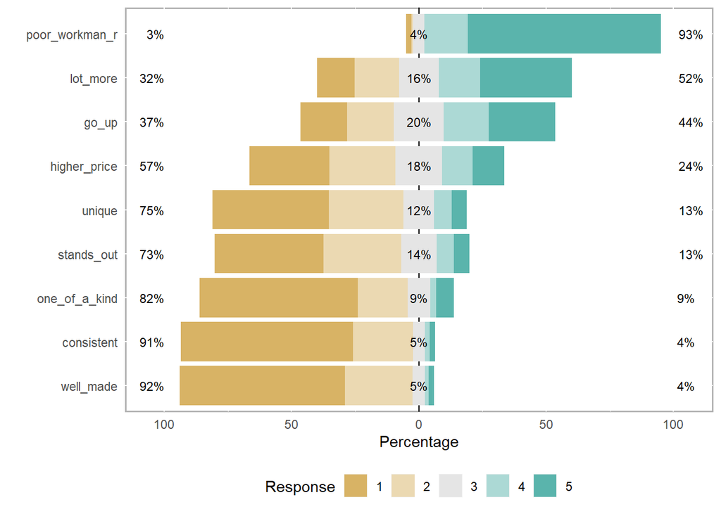

```r
# Plot response frequencies
result <- likert::likert(b_rep_likert)
plot(result)
```

```r
brand_qual <- file002 %>%
    mutate(tired=6-tired_r) %>%
    select(-innovator) %>%
    as.data.frame()
glimpse(brand_qual)
```

```
## Observations: 508
## Variables: 10
## $ trendy         <dbl> 2, 1, 1, 1, 1, 1, 1, 2, 2, 1, 1, 2, 2, 1, 1, 1, 2, 1...
## $ latest         <dbl> 1, 1, 1, 1, 1, 1, 1, 2, 2, 1, 1, 2, 2, 1, 1, 1, 1, 1...
## $ tired_r        <dbl> 2, 1, 1, 1, 1, 2, 1, 2, 1, 1, 1, 1, 3, 1, 1, 1, 1, 1...
## $ happy_pay      <dbl> 2, 1, 1, 2, 1, 2, 1, 2, 1, 1, 1, 2, 2, 1, 1, 1, 2, 1...
## $ reason_price   <dbl> 2, 1, 1, 2, 1, 2, 1, 1, 1, 1, 1, 2, 4, 1, 1, 2, 2, 1...
## $ good_deal      <dbl> 1, 2, 1, 1, 1, 1, 1, 1, 1, 1, 1, 2, 3, 1, 1, 2, 2, 2...
## $ strong_perform <dbl> 5, 2, 1, 1, 4, 5, 2, 3, 1, 1, 1, 4, 4, 4, 1, 2, 2, 1...
## $ leader         <dbl> 5, 3, 1, 4, 5, 5, 3, 5, 1, 1, 1, 5, 3, 5, 3, 5, 4, 3...
## $ serious        <dbl> 5, 3, 1, 3, 3, 5, 2, 5, 1, 1, 1, 5, 3, 5, 2, 1, 3, 3...
## $ tired          <dbl> 4, 5, 5, 5, 5, 4, 5, 4, 5, 5, 5, 5, 3, 5, 5, 5, 5, 5...
```

```r
brand_qual_items <- c('trendy = This brand is trendy.', 'latest = This brand offers the latest products.', 'tired = This is a tired brand.', "happy_pay = I am happy paying what I do for this brand's products.", "reason_price = This brand's products are reasonably priced.", "good_deal = This brand's products are a good deal.", "strong_perform = This brand's products are strong performers.", 'leader = This brand is a leader in its field.', 'serious = This brand takes its product quality seriously.')
brand_qual_items
```

```
## [1] "trendy = This brand is trendy."
## [2] "latest = This brand offers the latest products."
## [3] "tired = This is a tired brand."
## [4] "happy_pay = I am happy paying what I do for this brand's products."
## [5] "reason_price = This brand's products are reasonably priced."
## [6] "good_deal = This brand's products are a good deal."
## [7] "strong_perform = This brand's products are strong performers."
## [8] "leader = This brand is a leader in its field."
## [9] "serious = This brand takes its product quality seriously."
```

```r
# Get response frequencies from psych
psych::response.frequencies(brand_qual)
```

```
##                         1          2          3           4          5 miss
## trendy         0.84842520 0.11220472 0.01968504 0.007874016 0.01181102    0
## latest         0.81102362 0.13976378 0.01574803 0.013779528 0.01968504    0
## tired_r        0.80511811 0.13385827 0.03149606 0.015748031 0.01377953    0
## happy_pay      0.68110236 0.25393701 0.03149606 0.011811024 0.02165354    0
## reason_price   0.69685039 0.22440945 0.04133858 0.013779528 0.02362205    0
## good_deal      0.73228346 0.19685039 0.04921260 0.000000000 0.02165354    0
## strong_perform 0.33070866 0.24803150 0.14566929 0.127952756 0.14763780    0
## leader         0.18897638 0.14763780 0.10826772 0.185039370 0.37007874    0
## serious        0.23818898 0.18307087 0.15748031 0.141732283 0.27952756    0
## tired          0.01377953 0.01574803 0.03149606 0.133858268 0.80511811    0
```

```r
# Print item descriptions
brand_qual_items
```

```
## [1] "trendy = This brand is trendy."
## [2] "latest = This brand offers the latest products."
## [3] "tired = This is a tired brand."
## [4] "happy_pay = I am happy paying what I do for this brand's products."
## [5] "reason_price = This brand's products are reasonably priced."
## [6] "good_deal = This brand's products are a good deal."
## [7] "strong_perform = This brand's products are strong performers."
## [8] "leader = This brand is a leader in its field."
## [9] "serious = This brand takes its product quality seriously."
```

```r
# Reverse code the "opposite" item
brand_qual$tired_r <- car::recode(brand_qual$tired, "1 = 5; 2 = 4; 4 = 2; 5 = 1")

# Check recoding frequencies
brand_qual %>%
    select(tired, tired_r) %>%
    psych::response.frequencies() %>%
    round(2)
```

```
##            1    2    3    4    5 miss
## tired   0.01 0.02 0.03 0.13 0.81    0
## tired_r 0.81 0.13 0.03 0.02 0.01    0
```

```r
missing_lots <- file002 %>%
    mutate(tired=6-tired_r) %>%
    select(-tired_r)
set.seed(1908181013)
naRow <- sample(1:nrow(missing_lots), round(0.2*nrow(missing_lots)*ncol(missing_lots)), replace=TRUE)
naCol <- sample(1:ncol(missing_lots), round(0.2*nrow(missing_lots)*ncol(missing_lots)), replace=TRUE)
for (j in seq_along(naRow)) { missing_lots[naRow[j], naCol[j]] <- NA }
glimpse(missing_lots)
```

```
## Observations: 508
## Variables: 10
## $ trendy         <dbl> NA, 1, 1, NA, 1, NA, 1, 2, NA, 1, 1, 2, NA, 1, NA, 1...
## $ latest         <dbl> 1, 1, 1, 1, 1, NA, 1, NA, 2, 1, 1, 2, 2, 1, 1, 1, 1,...
## $ happy_pay      <dbl> 2, 1, NA, NA, 1, 2, 1, 2, 1, 1, 1, 2, NA, 1, NA, 1, ...
## $ reason_price   <dbl> 2, 1, 1, 2, 1, 2, 1, NA, NA, NA, 1, NA, NA, NA, NA, ...
## $ good_deal      <dbl> 1, 2, 1, 1, 1, 1, 1, 1, NA, 1, 1, 2, 3, NA, 1, 2, 2,...
## $ strong_perform <dbl> 5, NA, 1, 1, 4, 5, 2, 3, 1, 1, NA, 4, 4, NA, 1, 2, 2...
## $ leader         <dbl> 5, NA, 1, 4, 5, 5, 3, 5, 1, 1, 1, 5, 3, 5, 3, 5, 4, ...
## $ serious        <dbl> 5, 3, 1, 3, 3, NA, 2, 5, 1, 1, 1, 5, 3, 5, 2, 1, 3, ...
## $ innovator      <dbl> 5, 3, 5, 2, 2, 1, 3, 4, 1, 1, 5, 5, 2, NA, 4, 1, 4, ...
## $ tired          <dbl> 4, NA, NA, 5, 5, 4, 5, 4, NA, NA, 5, 5, 3, 5, 5, 5, ...
```

```r
# Total number of rows
nrow(missing_lots)
```

```
## [1] 508
```

```r
# Total number of incomplete cases
sum(!complete.cases(missing_lots))
```

```
## [1] 433
```

```r
# Number of incomplete cases by variable
colSums(is.na(missing_lots))
```

```
##         trendy         latest      happy_pay   reason_price      good_deal
##             97             94             87             92             83
## strong_perform         leader        serious      innovator          tired
##             91            108             86             97             81
```

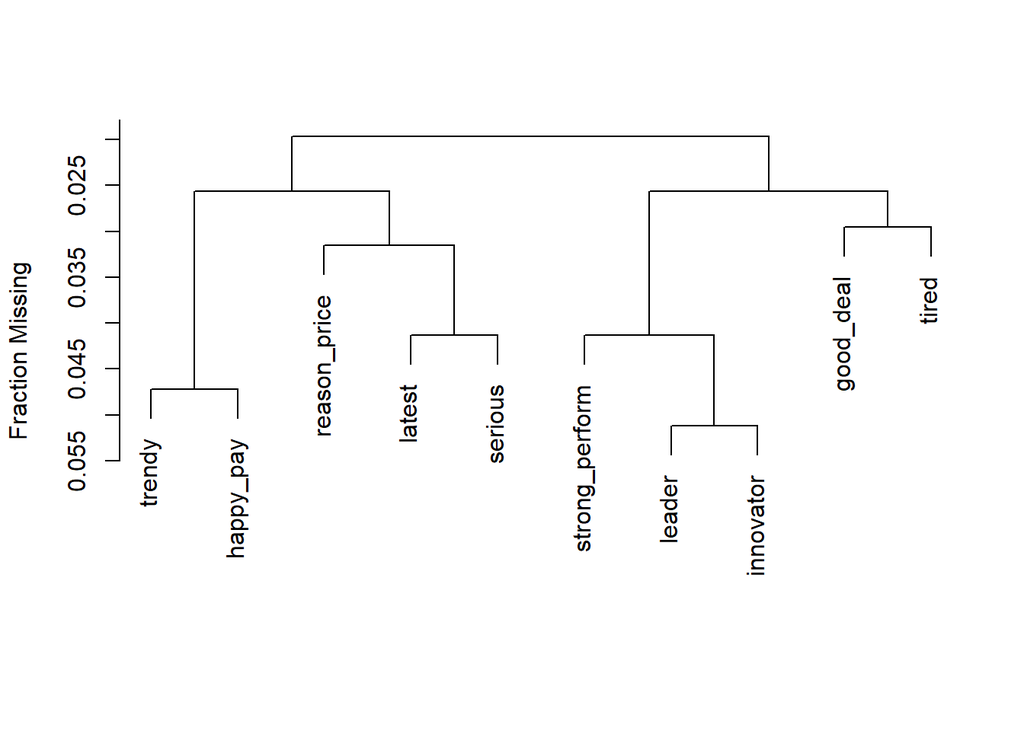

```r
# Hierarchical plot -- what values are missing together?
plot(Hmisc::naclus(missing_lots))
```

```r
brand_qual_9 <- file002
glimpse(brand_qual_9)
```

```
## Observations: 508
## Variables: 10
## $ trendy         <dbl> 2, 1, 1, 1, 1, 1, 1, 2, 2, 1, 1, 2, 2, 1, 1, 1, 2, 1...
## $ latest         <dbl> 1, 1, 1, 1, 1, 1, 1, 2, 2, 1, 1, 2, 2, 1, 1, 1, 1, 1...
## $ tired_r        <dbl> 2, 1, 1, 1, 1, 2, 1, 2, 1, 1, 1, 1, 3, 1, 1, 1, 1, 1...
## $ happy_pay      <dbl> 2, 1, 1, 2, 1, 2, 1, 2, 1, 1, 1, 2, 2, 1, 1, 1, 2, 1...
## $ reason_price   <dbl> 2, 1, 1, 2, 1, 2, 1, 1, 1, 1, 1, 2, 4, 1, 1, 2, 2, 1...
## $ good_deal      <dbl> 1, 2, 1, 1, 1, 1, 1, 1, 1, 1, 1, 2, 3, 1, 1, 2, 2, 2...
## $ strong_perform <dbl> 5, 2, 1, 1, 4, 5, 2, 3, 1, 1, 1, 4, 4, 4, 1, 2, 2, 1...
## $ leader         <dbl> 5, 3, 1, 4, 5, 5, 3, 5, 1, 1, 1, 5, 3, 5, 3, 5, 4, 3...
## $ serious        <dbl> 5, 3, 1, 3, 3, 5, 2, 5, 1, 1, 1, 5, 3, 5, 2, 1, 3, 3...
## $ innovator      <dbl> 5, 3, 5, 2, 2, 1, 3, 4, 1, 1, 5, 5, 2, 4, 4, 1, 4, 1...
```

```r
# View significance of item correlations
psych::corr.test(brand_qual_9)
```

```
## Call:psych::corr.test(x = brand_qual_9)
## Correlation matrix
##                trendy latest tired_r happy_pay reason_price good_deal
## trendy           1.00   0.76    0.55      0.41         0.41      0.42
## latest           0.76   1.00    0.57      0.46         0.48      0.49
## tired_r          0.55   0.57    1.00      0.38         0.41      0.41
## happy_pay        0.41   0.46    0.38      1.00         0.89      0.73
## reason_price     0.41   0.48    0.41      0.89         1.00      0.75
## good_deal        0.42   0.49    0.41      0.73         0.75      1.00
## strong_perform   0.30   0.35    0.30      0.43         0.40      0.28
## leader           0.12   0.17    0.12      0.23         0.21      0.12
## serious          0.18   0.23    0.18      0.31         0.29      0.19
## innovator        0.09   0.09    0.07      0.09         0.07      0.12
##                strong_perform leader serious innovator
## trendy                   0.30   0.12    0.18      0.09
## latest                   0.35   0.17    0.23      0.09
## tired_r                  0.30   0.12    0.18      0.07
## happy_pay                0.43   0.23    0.31      0.09
## reason_price             0.40   0.21    0.29      0.07
## good_deal                0.28   0.12    0.19      0.12
## strong_perform           1.00   0.67    0.72      0.06
## leader                   0.67   1.00    0.79      0.04
## serious                  0.72   0.79    1.00      0.06
## innovator                0.06   0.04    0.06      1.00
## Sample Size
## [1] 508
## Probability values (Entries above the diagonal are adjusted for multiple tests.)
##                trendy latest tired_r happy_pay reason_price good_deal
## trendy           0.00   0.00    0.00      0.00          0.0      0.00
## latest           0.00   0.00    0.00      0.00          0.0      0.00
## tired_r          0.00   0.00    0.00      0.00          0.0      0.00
## happy_pay        0.00   0.00    0.00      0.00          0.0      0.00
## reason_price     0.00   0.00    0.00      0.00          0.0      0.00
## good_deal        0.00   0.00    0.00      0.00          0.0      0.00
## strong_perform   0.00   0.00    0.00      0.00          0.0      0.00
## leader           0.01   0.00    0.01      0.00          0.0      0.01
## serious          0.00   0.00    0.00      0.00          0.0      0.00
## innovator        0.03   0.04    0.14      0.05          0.1      0.01
##                strong_perform leader serious innovator
## trendy                    0.0   0.08     0.0      0.26
## latest                    0.0   0.00     0.0      0.31
## tired_r                   0.0   0.08     0.0      0.56
## happy_pay                 0.0   0.00     0.0      0.31
## reason_price              0.0   0.00     0.0      0.51
## good_deal                 0.0   0.08     0.0      0.08
## strong_perform            0.0   0.00     0.0      0.61
## leader                    0.0   0.00     0.0      0.61
## serious                   0.0   0.00     0.0      0.61
## innovator                 0.2   0.39     0.2      0.00
##
##  To see confidence intervals of the correlations, print with the short=FALSE option
```

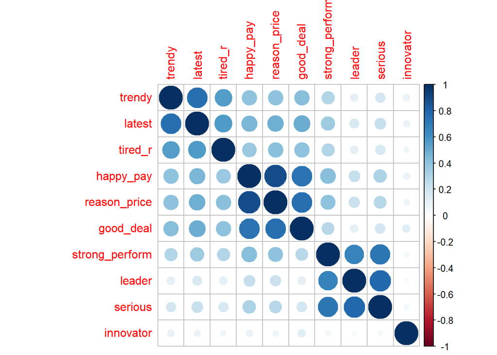

```r
# Visualize item correlations -- corrplot
corrplot::corrplot(cor(brand_qual_9), method = "circle")
```

```r
b_rep_items <- c("well_made: Crunchola's products are well-made.", 'consistent: Crunchola offers consistently high-quality products.', 'poor_workman: Crunchola suffers from poor workmanship in its products.', 'higher_price: I am willing to pay a higher price for Crunchola products.', 'lot_more: I am willing to pay a lot more for Crunchola products.', 'go_up: The price of Crunchola products would have to go up quite a bit before I would switch to another brand.', "stands_out: Crunchola's brand really stands out from its competitors.", "unique: Crunchola's brand is unique from other brands.", "one_of_a_kind: Crunchola's brand is truly one of a kind.")
b_rep_items
```

```
## [1] "well_made: Crunchola's products are well-made."
## [2] "consistent: Crunchola offers consistently high-quality products."
## [3] "poor_workman: Crunchola suffers from poor workmanship in its products."
## [4] "higher_price: I am willing to pay a higher price for Crunchola products."
## [5] "lot_more: I am willing to pay a lot more for Crunchola products."
## [6] "go_up: The price of Crunchola products would have to go up quite a bit before I would switch to another brand."
## [7] "stands_out: Crunchola's brand really stands out from its competitors."
## [8] "unique: Crunchola's brand is unique from other brands."
## [9] "one_of_a_kind: Crunchola's brand is truly one of a kind."
```

```r
brand_rep_9 <- file001 %>%
    mutate(poor_workman = 6-poor_workman_r) %>%
    select(-poor_workman_r) %>%
    as.data.frame()
glimpse(brand_rep_9)
```

```
## Observations: 559
## Variables: 9
## $ well_made     <dbl> 1, 1, 1, 5, 1, 1, 1, 1, 1, 1, 3, 1, 1, 2, 1, 2, 1, 1,...
## $ consistent    <dbl> 1, 1, 1, 3, 1, 1, 1, 1, 1, 1, 2, 1, 1, 2, 1, 2, 1, 1,...
## $ higher_price  <dbl> 1, 3, 2, 5, 1, 4, 1, 3, 1, 1, 2, 3, 2, 3, 1, 2, 2, 2,...
## $ lot_more      <dbl> 1, 5, 2, 5, 1, 5, 3, 3, 1, 5, 2, 5, 5, 2, 3, 4, 5, 4,...
## $ go_up         <dbl> 1, 5, 2, 5, 1, 5, 1, 3, 2, 5, 3, 5, 5, 2, 3, 4, 3, 4,...
## $ stands_out    <dbl> 1, 1, 2, 5, 1, 1, 1, 3, 2, 1, 2, 3, 1, 3, 2, 2, 2, 3,...
## $ unique        <dbl> 1, 1, 2, 5, 1, 1, 1, 3, 3, 1, 2, 5, 1, 2, 3, 2, 1, 3,...
## $ one_of_a_kind <dbl> 1, 4, 1, 5, 1, 2, 1, 1, 1, 1, 2, 1, 2, 3, 1, 2, 1, 1,...
## $ poor_workman  <dbl> 5, 4, 5, 1, 5, 5, 5, 5, 5, 5, 4, 5, 2, 5, 5, 3, 5, 5,...
```

```r
# Get response frequencies
psych::response.frequencies(brand_rep_9)
```

```
##                       1           2          3          4          5 miss
## well_made     0.6493739 0.266547406 0.04830054 0.01431127 0.02146691    0
## consistent    0.6779964 0.234347048 0.04651163 0.01967800 0.02146691    0
## higher_price  0.3130590 0.259391771 0.18425760 0.11985689 0.12343470    0
## lot_more      0.1484794 0.173524150 0.15563506 0.16279070 0.35957066    0
## go_up         0.1842576 0.182468694 0.19677996 0.17710197 0.25939177    0
## stands_out    0.4275492 0.304114490 0.13953488 0.06797853 0.06082290    0
## unique        0.4579606 0.293381038 0.11985689 0.06976744 0.05903399    0
## one_of_a_kind 0.6225403 0.194991055 0.08944544 0.02325581 0.06976744    0
## poor_workman  0.0196780 0.007155635 0.04472272 0.16994633 0.75849732    0
```

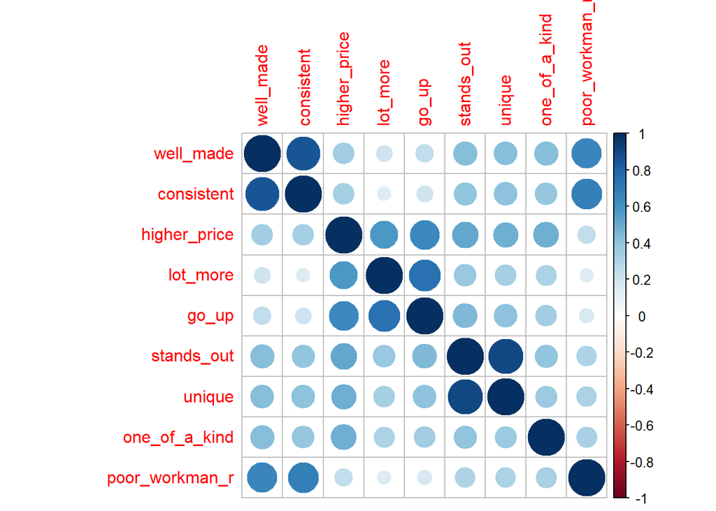

```r
# Recode the appropriate item
brand_rep_9$poor_workman_r <- car::recode(brand_rep_9$poor_workman, "1 = 5; 2 = 4; 4 = 2; 5 = 1")

# Adjust brandrep 9 dataset
brand_rep_9_new <- select(brand_rep_9, -poor_workman)

# Visualize item correlation
corrplot::corrplot(cor(brand_rep_9_new), method = "circle")
```

Chapter 2 - Exploratory Factor Analysis and Survey Development

Latent Variables:

- Latent variables are inferred from manifest variables - for example, brand loyalty
- Parsimony is a general goal of survey development - how do the manifest variables help identify the latent variables
  - psych::fa.parallel(myDF) # scree of dataset against random dataset
  - myEFA <- psych::fa(myDF, nfactors=3)
  - myEFA$loadings
  - psych::scree(myDF)

EFA and Item Refinement:

- Factor loadings are a valuable statistic - relationship between manifest variables and latent variables
  - Ideally, only one latent variable per manifest variables
  - 0 - 0.4 are poor
  - 0.7+ are strong
  - 0.4 - 0.7 are equivocal
- What makes for a strong EFA?
  - c_sat_11_EFA_3$e.values # check that the number of eigenvalues >1 is the same as the number of factors (rule of thumb)
  - Factor score correlations of 0.6 and under are “not too similar”
  - myEFA$score.cor
- If results are not favorable can either 1) drop poorly performing items, or 2) revist the number of factors

Assessing Internal Reliability:

- Internal consistency is a measure of survey reliability - consistency within itself
- Split-half reliability checks whether all parts of the survey contribute equally
  - psych::splitHalf(mySurvey) # generally, 0.8+ indicates internal reliability
- Coefficient (Cornbach) alpha measures the consistency of measures of the construct
  - psych::alpha(mySurvey) # std.alpha is considered a more reliable metric due to standardization
  - Target is 0.8 - 0.9 with 0.7 - 0.8 also respectable and 0.65 - 0.7 minimally acceptable
  - Values > 0.9 may suggest collinearity problems; drop items
  - Values < 0.65 are undesirable and/or unacceptable; drop items as they may not be measuring the same construct

Example code includes:

```r
b_loyal_10 <- file004
glimpse(b_loyal_10)
```

```
## Observations: 639
## Variables: 10
## $ BL1  <dbl> 5, 4, 5, 4, 4, 4, 5, 3, 4, 3, 4, 4, 5, 5, 4, 4, 3, 4, 5, 3, 4,...
## $ BL2  <dbl> 4, 3, 3, 4, 5, 4, 5, 4, 4, 3, 4, 5, 4, 5, 5, 5, 3, 4, 5, 4, 3,...
## $ BL3  <dbl> 4, 4, 5, 2, 4, 4, 5, 3, 4, 4, 4, 4, 5, 5, 5, 5, 3, 4, 5, 3, 5,...
## $ BL4  <dbl> 4, 3, 3, 2, 4, 4, 3, 3, 4, 2, 3, 4, 4, 4, 4, 3, 3, 3, 4, 3, 2,...
## $ BL5  <dbl> 4, 3, 3, 2, 4, 3, 4, 3, 4, 2, 4, 5, 5, 4, 4, 4, 3, 4, 5, 2, 2,...
## $ BL6  <dbl> 4, 3, 4, 2, 4, 4, 5, 3, 4, 3, 4, 5, 3, 5, 4, 3, 3, 3, 5, 3, 4,...
## $ BL7  <dbl> 3, 3, 2, 2, 3, 2, 4, 1, 4, 3, 1, 5, 4, 5, 3, 3, 3, 2, 4, 4, 1,...
## $ BL8  <dbl> 4, 1, 2, 4, 4, 2, 4, 3, 4, 3, 4, 5, 3, 5, 4, 4, 2, 4, 5, 2, 1,...
## $ BL9  <dbl> 3, 1, 2, 2, 4, 2, 4, 3, 4, 3, 4, 5, 3, 5, 2, 3, 3, 1, 3, 4, 1,...
## $ BL10 <dbl> 3, 1, 3, 2, 4, 2, 4, 3, 4, 2, 3, 5, 2, 3, 3, 2, 3, 1, 5, 4, 2,...
```

```r
# Print correlation matrix
psych::corr.test(b_loyal_10)
```

```
## Call:psych::corr.test(x = b_loyal_10)
## Correlation matrix
##       BL1  BL2  BL3  BL4  BL5  BL6  BL7  BL8  BL9 BL10
## BL1  1.00 0.44 0.50 0.35 0.38 0.40 0.15 0.22 0.22 0.16
## BL2  0.44 1.00 0.52 0.36 0.42 0.37 0.19 0.29 0.27 0.20
## BL3  0.50 0.52 1.00 0.38 0.49 0.45 0.28 0.27 0.30 0.20
## BL4  0.35 0.36 0.38 1.00 0.50 0.47 0.29 0.34 0.30 0.14
## BL5  0.38 0.42 0.49 0.50 1.00 0.63 0.39 0.37 0.39 0.25
## BL6  0.40 0.37 0.45 0.47 0.63 1.00 0.36 0.40 0.39 0.28
## BL7  0.15 0.19 0.28 0.29 0.39 0.36 1.00 0.50 0.64 0.48
## BL8  0.22 0.29 0.27 0.34 0.37 0.40 0.50 1.00 0.65 0.46
## BL9  0.22 0.27 0.30 0.30 0.39 0.39 0.64 0.65 1.00 0.60
## BL10 0.16 0.20 0.20 0.14 0.25 0.28 0.48 0.46 0.60 1.00
## Sample Size
## [1] 639
## Probability values (Entries above the diagonal are adjusted for multiple tests.)
##      BL1 BL2 BL3 BL4 BL5 BL6 BL7 BL8 BL9 BL10
## BL1    0   0   0   0   0   0   0   0   0    0
## BL2    0   0   0   0   0   0   0   0   0    0
## BL3    0   0   0   0   0   0   0   0   0    0
## BL4    0   0   0   0   0   0   0   0   0    0
## BL5    0   0   0   0   0   0   0   0   0    0
## BL6    0   0   0   0   0   0   0   0   0    0
## BL7    0   0   0   0   0   0   0   0   0    0
## BL8    0   0   0   0   0   0   0   0   0    0
## BL9    0   0   0   0   0   0   0   0   0    0
## BL10   0   0   0   0   0   0   0   0   0    0
##
##  To see confidence intervals of the correlations, print with the short=FALSE option
```

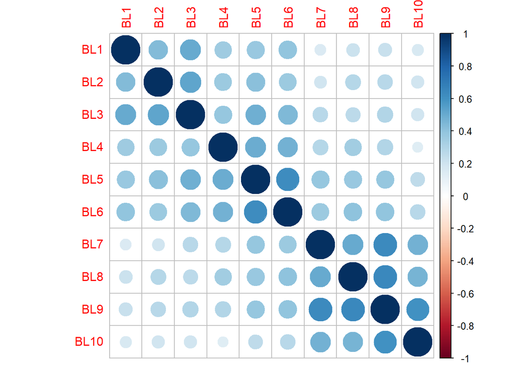

```r
# Visualize b_loyal_10 correlation matrix
corrplot::corrplot(cor(b_loyal_10))
```

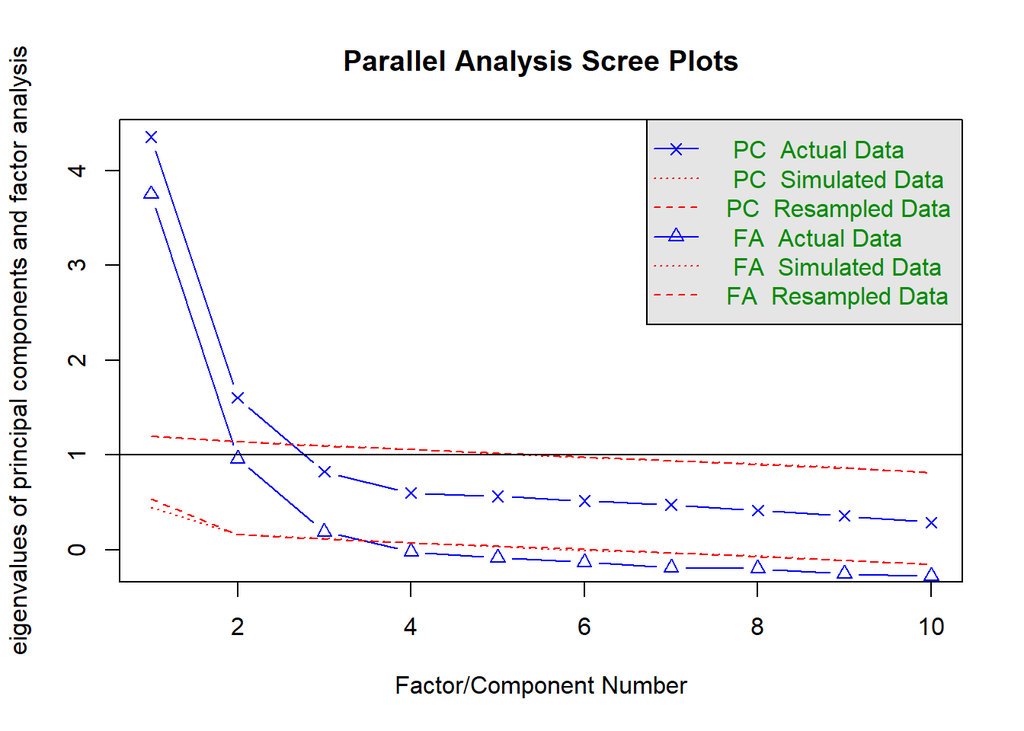

```
## Parallel analysis suggests that the number of factors =  3  and the number of components =  2
```

```r
# Parallel analysis
psych::fa.parallel(b_loyal_10)
```

```r
brand_rep_9 <- file001 %>%
    mutate(poor_workman = 6-poor_workman_r) %>%
    select(-poor_workman) %>%
    as.data.frame()
glimpse(brand_rep_9)
```

```
## Observations: 559
## Variables: 9
## $ well_made      <dbl> 1, 1, 1, 5, 1, 1, 1, 1, 1, 1, 3, 1, 1, 2, 1, 2, 1, 1...
## $ consistent     <dbl> 1, 1, 1, 3, 1, 1, 1, 1, 1, 1, 2, 1, 1, 2, 1, 2, 1, 1...
## $ poor_workman_r <dbl> 1, 2, 1, 5, 1, 1, 1, 1, 1, 1, 2, 1, 4, 1, 1, 3, 1, 1...
## $ higher_price   <dbl> 1, 3, 2, 5, 1, 4, 1, 3, 1, 1, 2, 3, 2, 3, 1, 2, 2, 2...
## $ lot_more       <dbl> 1, 5, 2, 5, 1, 5, 3, 3, 1, 5, 2, 5, 5, 2, 3, 4, 5, 4...
## $ go_up          <dbl> 1, 5, 2, 5, 1, 5, 1, 3, 2, 5, 3, 5, 5, 2, 3, 4, 3, 4...
## $ stands_out     <dbl> 1, 1, 2, 5, 1, 1, 1, 3, 2, 1, 2, 3, 1, 3, 2, 2, 2, 3...
## $ unique         <dbl> 1, 1, 2, 5, 1, 1, 1, 3, 3, 1, 2, 5, 1, 2, 3, 2, 1, 3...
## $ one_of_a_kind  <dbl> 1, 4, 1, 5, 1, 2, 1, 1, 1, 1, 2, 1, 2, 3, 1, 2, 1, 1...
```

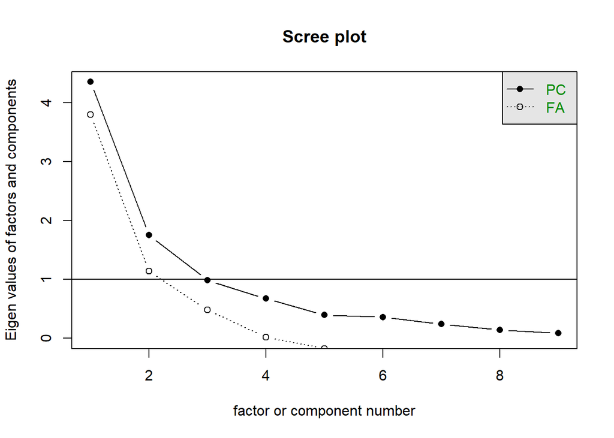

```r
# Scree plot
psych::scree(brand_rep_9)
```

```r
# Conduct three-factor EFA
brand_rep_9_EFA <- psych::fa(brand_rep_9, nfactors = 3)
# Print output of EFA
names(brand_rep_9_EFA)
```

```
##  [1] "residual"      "dof"           "chi"           "nh"
##  [5] "rms"           "EPVAL"         "crms"          "EBIC"
##  [9] "ESABIC"        "fit"           "fit.off"       "sd"
## [13] "factors"       "complexity"    "n.obs"         "objective"
## [17] "criteria"      "STATISTIC"     "PVAL"          "Call"
## [21] "null.model"    "null.dof"      "null.chisq"    "TLI"
## [25] "RMSEA"         "BIC"           "SABIC"         "r.scores"
## [29] "R2"            "valid"         "score.cor"     "weights"
## [33] "rotation"      "communality"   "communalities" "uniquenesses"
## [37] "values"        "e.values"      "loadings"      "model"
## [41] "fm"            "rot.mat"       "Phi"           "Structure"
## [45] "method"        "scores"        "R2.scores"     "r"
## [49] "np.obs"        "fn"            "Vaccounted"
```

```r
# Summarize results of three-factor EFA
summary(brand_rep_9_EFA)
```

```
##
## Factor analysis with Call: psych::fa(r = brand_rep_9, nfactors = 3)
##
## Test of the hypothesis that 3 factors are sufficient.
## The degrees of freedom for the model is 12  and the objective function was  0.08
## The number of observations was  559  with Chi Square =  43.11  with prob <  2.2e-05
##
## The root mean square of the residuals (RMSA) is  0.02
## The df corrected root mean square of the residuals is  0.03
##
## Tucker Lewis Index of factoring reliability =  0.972
## RMSEA index =  0.068  and the 10 % confidence intervals are  0.047 0.091
## BIC =  -32.8
##  With factor correlations of
##      MR2  MR1  MR3
## MR2 1.00 0.29 0.46
## MR1 0.29 1.00 0.51
## MR3 0.46 0.51 1.00
```

```r
# Build and print loadings for a two-factor EFA
brand_rep_9_EFA_2 <- psych::fa(brand_rep_9, nfactors = 2)
brand_rep_9_EFA_2$loadings
```

```
##
## Loadings:
##                MR1    MR2
## well_made              0.884
## consistent             0.932
## poor_workman_r         0.728
## higher_price    0.745
## lot_more        0.784 -0.131
## go_up           0.855 -0.103
## stands_out      0.591  0.286
## unique          0.540  0.307
## one_of_a_kind   0.378  0.305
##
##                  MR1   MR2
## SS loadings    2.688 2.485
## Proportion Var 0.299 0.276
## Cumulative Var 0.299 0.575
```

```r
# Build and print loadings for a four-factor EFA
brand_rep_9_EFA_4 <- psych::fa(brand_rep_9, nfactors = 4)
brand_rep_9_EFA_4$loadings
```

```
##
## Loadings:
##                MR2    MR1    MR3    MR4
## well_made       0.879
## consistent      0.964
## poor_workman_r  0.732
## higher_price           0.552  0.150  0.168
## lot_more               0.835
## go_up                  0.929
## stands_out                    0.976
## unique                        0.932
## one_of_a_kind                        0.999
##
##                  MR2   MR1   MR3   MR4
## SS loadings    2.244 1.866 1.846 1.029
## Proportion Var 0.249 0.207 0.205 0.114
## Cumulative Var 0.249 0.457 0.662 0.776
```

```r
# (Factor loadings greater than 1, while rare, are not necessarily an issue.)

# Three factor EFA - brand_rep_9
brand_rep_9_EFA_3 <- psych::fa(brand_rep_9, nfactors = 3)

# Eigenvalues
brand_rep_9_EFA_3$e.values
```

```
## [1] 4.35629549 1.75381015 0.98701607 0.67377072 0.39901205 0.35865598 0.23915591
## [8] 0.14238807 0.08989556
```

```r
# Factor score correlations
brand_rep_9_EFA_3$score.cor
```

```
##           [,1]      [,2]      [,3]
## [1,] 1.0000000 0.3687866 0.4733475
## [2,] 0.3687866 1.0000000 0.4977679
## [3,] 0.4733475 0.4977679 1.0000000
```

```r
# Factor loadings
brand_rep_9_EFA_3$loadings
```

```
##
## Loadings:
##                MR2    MR1    MR3
## well_made       0.896
## consistent      0.947
## poor_workman_r  0.739
## higher_price    0.127  0.632  0.149
## lot_more               0.850
## go_up                  0.896
## stands_out                    1.008
## unique                        0.896
## one_of_a_kind   0.309  0.295  0.115
##
##                  MR2   MR1   MR3
## SS loadings    2.361 2.012 1.858
## Proportion Var 0.262 0.224 0.206
## Cumulative Var 0.262 0.486 0.692
```

```r
# Create brand_rep_8 data frame
brand_rep_8 <- brand_rep_9 %>% select(-one_of_a_kind)

# Create three-factor EFA
brand_rep_8_EFA_3 <- psych::fa(brand_rep_8, nfactors=3)

# Factor loadings
brand_rep_8_EFA_3$loadings
```

```
##
## Loadings:
##                MR2    MR3    MR1
## well_made       0.887
## consistent      0.958
## poor_workman_r  0.735
## higher_price    0.120  0.596  0.170
## lot_more               0.845
## go_up                  0.918
## stands_out                    0.990
## unique                        0.916
##
##                  MR2   MR3   MR1
## SS loadings    2.261 1.915 1.850
## Proportion Var 0.283 0.239 0.231
## Cumulative Var 0.283 0.522 0.753
```

```r
# Factor correlations -- 9 versus 8 item model
brand_rep_8_EFA_3$score.cor
```

```
##           [,1]      [,2]      [,3]
## [1,] 1.0000000 0.2826536 0.4247302
## [2,] 0.2826536 1.0000000 0.4977679
## [3,] 0.4247302 0.4977679 1.0000000
```

```r
brand_rep_9_EFA_3$score.cor
```

```
##           [,1]      [,2]      [,3]
## [1,] 1.0000000 0.3687866 0.4733475
## [2,] 0.3687866 1.0000000 0.4977679
## [3,] 0.4733475 0.4977679 1.0000000
```

```r
# Three factor EFA loadings
brand_rep_8_EFA_3$loadings
```

```
##
## Loadings:
##                MR2    MR3    MR1
## well_made       0.887
## consistent      0.958
## poor_workman_r  0.735
## higher_price    0.120  0.596  0.170
## lot_more               0.845
## go_up                  0.918
## stands_out                    0.990
## unique                        0.916
##
##                  MR2   MR3   MR1
## SS loadings    2.261 1.915 1.850
## Proportion Var 0.283 0.239 0.231
## Cumulative Var 0.283 0.522 0.753
```

```r
# Two factor EFA & loadings
brand_rep_8_EFA_2 <- psych::fa(brand_rep_8, nfactors = 2)
brand_rep_8_EFA_2$loadings
```

```
##
## Loadings:
##                MR1    MR2
## well_made              0.878
## consistent             0.937
## poor_workman_r         0.725
## higher_price    0.724
## lot_more        0.782 -0.124
## go_up           0.859
## stands_out      0.595  0.293
## unique          0.546  0.315
##
##                  MR1   MR2
## SS loadings    2.529 2.392
## Proportion Var 0.316 0.299
## Cumulative Var 0.316 0.615
```

```r
# Four factor EFA & loadings
brand_rep_8_EFA_4 <- psych::fa(brand_rep_8, nfactors = 4)
brand_rep_8_EFA_4$loadings
```

```
##
## Loadings:
##                MR2    MR3    MR1    MR4
## well_made       0.831
## consistent      1.011               -0.126
## poor_workman_r  0.699                0.253
## higher_price    0.129  0.601  0.168
## lot_more               0.850
## go_up                  0.913
## stands_out                    0.992
## unique                        0.915
##
##                  MR2   MR3   MR1   MR4
## SS loadings    2.220 1.920 1.854 0.097
## Proportion Var 0.278 0.240 0.232 0.012
## Cumulative Var 0.278 0.518 0.749 0.761
```

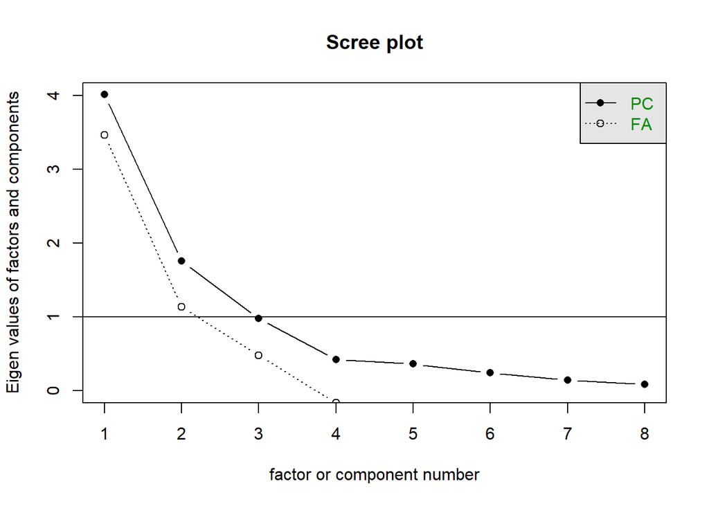

```r
# Scree plot of brand_rep_8
psych::scree(brand_rep_8)
```

```r
# Standardized coefficient alpha
psych::alpha(brand_rep_9)$total$std.alpha
```

```
## [1] 0.8648896
```

```r
# 3-factor EFA
brand_rep_9_EFA_3 <- psych::fa(brand_rep_9, nfactors = 3)
brand_rep_9_EFA_3$loadings
```

```
##
## Loadings:
##                MR2    MR1    MR3
## well_made       0.896
## consistent      0.947
## poor_workman_r  0.739
## higher_price    0.127  0.632  0.149
## lot_more               0.850
## go_up                  0.896
## stands_out                    1.008
## unique                        0.896
## one_of_a_kind   0.309  0.295  0.115
##
##                  MR2   MR1   MR3
## SS loadings    2.361 2.012 1.858
## Proportion Var 0.262 0.224 0.206
## Cumulative Var 0.262 0.486 0.692
```

```r
# Standardized coefficient alpha - refined scale
psych::alpha(brand_rep_8)$total$std.alpha
```

```
## [1] 0.8557356
```

```r
# A survey with poorly-loading items can still be reliable – that's why we do EFA first
# Remember that a reliable survey in itself is not the goal of measurement – it is necessary but not sufficient


# Get names of survey items
names(brand_rep_8)
```

```
## [1] "well_made"      "consistent"     "poor_workman_r" "higher_price"
## [5] "lot_more"       "go_up"          "stands_out"     "unique"
```

```r
# Create new data frames for each of three dimensions
p_quality <- brand_rep_8 %>% select(1:3)
p_willingness <- brand_rep_8 %>% select(4:6)
# p_difference <- brand_rep_8 %>% select(7:8)

# Check the standardized alpha for each dimension
psych::alpha(p_quality)$total$std.alpha
```

```
## [1] 0.8918025
```

```r
psych::alpha(p_willingness)$total$std.alpha
```

```
## [1] 0.8517566
```

```r
# psych::alpha(p_difference)$total$std.alpha
psych::alpha(brand_rep_8)$total$std.alpha
```

```
## [1] 0.8557356
```

```r
# Get split-half reliability
psych::splitHalf(brand_rep_8)
```

```
## Split half reliabilities
## Call: psych::splitHalf(r = brand_rep_8)
##
## Maximum split half reliability (lambda 4) =  0.93
## Guttman lambda 6                          =  0.92
## Average split half reliability            =  0.86
## Guttman lambda 3 (alpha)                  =  0.86
## Guttman lambda 2                          =  0.87
## Minimum split half reliability  (beta)    =  0.66
## Average interitem r =  0.43  with median =  0.4
```

```r
# Get averages of even and odd row scores
odd_scores <- rowMeans(brand_rep_8[c(TRUE, FALSE), ])
even_scores <- rowMeans(brand_rep_8[c(FALSE,TRUE), ])

# Correlate scores from even and odd items
cor(odd_scores[1:length(even_scores)], even_scores)
```

```
## [1] 0.08827582
```

```r
# 3 factor EFA
b_loyal_10_EFA_3 <- psych::fa(b_loyal_10, nfactors = 3)

# Factor loadings, eigenvalues and factor score correlations
b_loyal_10_EFA_3$loadings
```

```
##
## Loadings:
##      MR2    MR1    MR3
## BL1                 0.643
## BL2                 0.682
## BL3                 0.700
## BL4          0.545  0.124
## BL5          0.772
## BL6          0.712
## BL7   0.643  0.207 -0.114
## BL8   0.619  0.165
## BL9   0.903
## BL10  0.718 -0.134
##
##                  MR2   MR1   MR3
## SS loadings    2.134 1.495 1.406
## Proportion Var 0.213 0.149 0.141
## Cumulative Var 0.213 0.363 0.503
```

```r
b_loyal_10_EFA_3$e.values
```

```
##  [1] 4.3564537 1.6031839 0.8242739 0.5982539 0.5649528 0.5155507 0.4767388
##  [8] 0.4136564 0.3594158 0.2875202
```

```r
b_loyal_10_EFA_3$score.cor
```

```
##           [,1]      [,2]      [,3]
## [1,] 1.0000000 0.4795981 0.3440793
## [2,] 0.4795981 1.0000000 0.5924107
## [3,] 0.3440793 0.5924107 1.0000000
```

```r
# 2 factor EFA
b_loyal_10_EFA_2 <- psych::fa(b_loyal_10, nfactors = 2)

# Factor loadings, eigenvalues and factor score correlations
b_loyal_10_EFA_2$loadings
```

```
##
## Loadings:
##      MR1    MR2
## BL1   0.673 -0.111
## BL2   0.654
## BL3   0.746
## BL4   0.581
## BL5   0.661  0.129
## BL6   0.616  0.161
## BL7          0.701
## BL8   0.116  0.657
## BL9          0.901
## BL10         0.688
##
##                  MR1   MR2
## SS loadings    2.610 2.270
## Proportion Var 0.261 0.227
## Cumulative Var 0.261 0.488
```

```r
b_loyal_10_EFA_2$e.values
```

```
##  [1] 4.3564537 1.6031839 0.8242739 0.5982539 0.5649528 0.5155507 0.4767388
##  [8] 0.4136564 0.3594158 0.2875202
```

```r
b_loyal_10_EFA_2$score.cor
```

```
##           [,1]      [,2]
## [1,] 1.0000000 0.4623472
## [2,] 0.4623472 1.0000000
```

Chapter 3 - Confirmatory Factor Analysis and Construct Validation

CFA and EFA:

- Confirmatory Factor Analysis (CFA) is a means of construct validation
  - Do the number of factors reflected in the data match theory and hypotheses
- Can use the lavaan package for latent variable analysis
  - la(tent) va(riable) an(alaysis)
  - Use =~ to assign items to factors
- Example for using lavaan on the 9-item survey
  - bq_9_CFAModel <- “VAL =~ reason_price + happy_pay + good deal PERF =~ serious + leader + strong_perform FUN =~ trendy + latest + tired_r”
  - bq_9_CFA <- cfa(model = bq_9_CFAModel, data=bq_9)
  - summary(bq_9_CFA, fit.measures=TRUE, standardized=TRUE)
  - inspect(bq_9_CFA, “std”)$lambda
  - semPlot::semPaths(bq_9_CFA)

CFA Assumptions and Interpretation:

- Can test for multivariate normality - p-values for skewness and kurtosis
  - psych::mardia(myData)
- The default for lavaan is maximum likelihood, which assumes normality
  - Can instead use MLR to mitigate non-normality
  - bq_cfa <- cfa(model=myModel, data=myData, estimator=“MLR”)
- Can look at fit measures and assess model performance
  - CFI (comparative fit index) - should be 0.9+
  - TLI (Tucker Lewis Index) - should be 0.9+
  - Chi-squared - should be < 0.05 (though often will be for large sample sizes, even with a bad model)
  - RMSEA - ideally less than 0.05
- Can use the fit measures function to get 42 fit measures
  - fitMeasures(myModel)
  - fitMeasures(myModel, fit.measures=c(“cfi”, “tli”))
- Can inspect estimates using standardizedSolution()
  - standardizedSolution(myModel)

Construct Validity:

- Construct validity is the extent to which the actual measurements and the claims of what is being measured are congruent
  - Validity is like being centered on a bullseye
  - Reliability is based on being tightly clustered around the mean
- If two dimensions are measuring the same things, then they should be combined in the interests of parsimony
  - semTools::reliability(myModel)
- Discriminant validity means that items should be distinct, but not unrelated
  - avevar should be 0.5+
  - CR (omega) should be 0.7+
  - alpha (Cronbach) should be 0.7+

Example code includes:

```r
brand_rep_EFA <- brand_rep_8_EFA_3
brand_rep_8_model <- 'F1 =~ well_made + consistent + poor_workman_r
F2 =~ higher_price + lot_more + go_up
F3 =~ stands_out + unique'
brand_rep_CFA <- lavaan::cfa(model=brand_rep_8_model, data=brand_rep_8)


# Factor loadings -- EFA
brand_rep_EFA$loadings
```

```
##
## Loadings:
##                MR2    MR3    MR1
## well_made       0.887
## consistent      0.958
## poor_workman_r  0.735
## higher_price    0.120  0.596  0.170
## lot_more               0.845
## go_up                  0.918
## stands_out                    0.990
## unique                        0.916
##
##                  MR2   MR3   MR1
## SS loadings    2.261 1.915 1.850
## Proportion Var 0.283 0.239 0.231
## Cumulative Var 0.283 0.522 0.753
```

```r
# Factor loadings -- CFA
lavaan::inspect(brand_rep_CFA, what = "std")$lambda
```

```
##                   F1    F2    F3
## well_made      0.914 0.000 0.000
## consistent     0.932 0.000 0.000
## poor_workman_r 0.730 0.000 0.000
## higher_price   0.000 0.733 0.000
## lot_more       0.000 0.812 0.000
## go_up          0.000 0.902 0.000
## stands_out     0.000 0.000 0.976
## unique         0.000 0.000 0.930
```

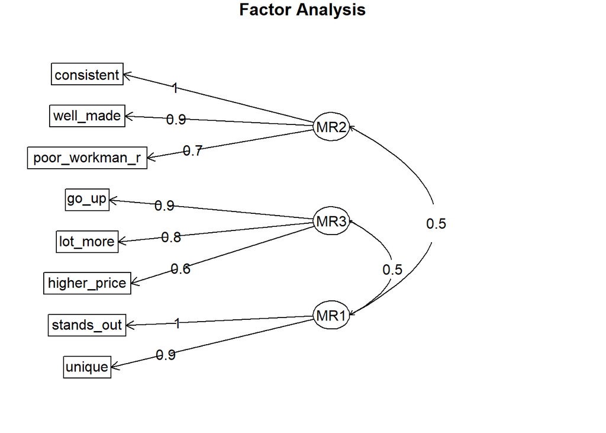

```r
# Plot diagram -- EFA
psych::fa.diagram(brand_rep_EFA)
```

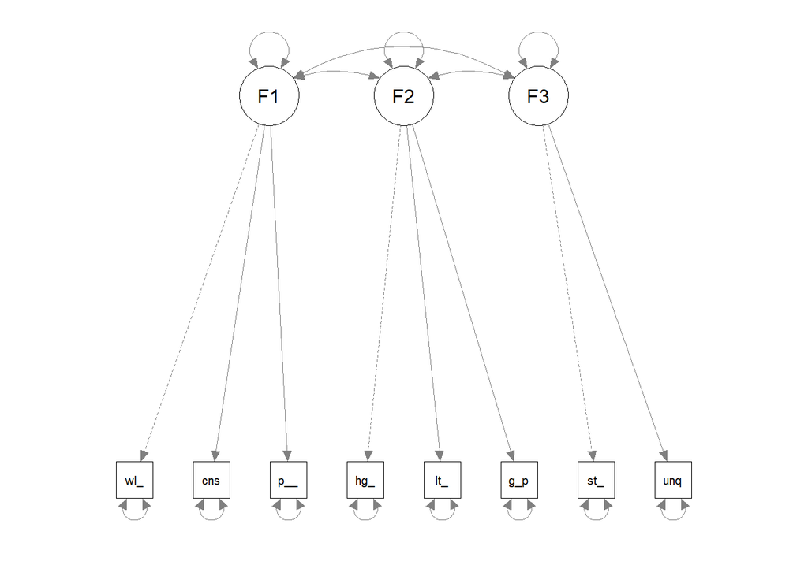

```r
# Plot diagram -- CFA
semPlot::semPaths(brand_rep_CFA)
```

```r
# Rename items based on proposed dimensions
colnames(b_loyal_10) <- c("ID1", "ID2", "ID3", "PV1", "PV2", "PV3", "BT1", "BT2", "BT3", "BT4")

# Define the model
b_loyal_cfa_model <- 'ID =~ ID1 + ID2 + ID3
                    PV =~ PV1 + PV2 + PV3
                    BT =~ BT1 + BT2 + BT3 + BT4'

# Fit the model to the data
b_loyal_cfa <- lavaan::cfa(model=b_loyal_cfa_model, data=b_loyal_10)

# Check the summary statistics -- include fit measures and standardized estimates
summary(b_loyal_cfa, fit.measures=TRUE, standardized=TRUE)
```

```
## lavaan 0.6-5 ended normally after 33 iterations
##
##   Estimator                                         ML
##   Optimization method                           NLMINB
##   Number of free parameters                         23
##
##   Number of observations                           639
##
## Model Test User Model:
##
##   Test statistic                                63.953
##   Degrees of freedom                                32
##   P-value (Chi-square)                           0.001
##
## Model Test Baseline Model:
##
##   Test statistic                              2485.786
##   Degrees of freedom                                45
##   P-value                                        0.000
##
## User Model versus Baseline Model:
##
##   Comparative Fit Index (CFI)                    0.987
##   Tucker-Lewis Index (TLI)                       0.982
##
## Loglikelihood and Information Criteria:
##
##   Loglikelihood user model (H0)              -7214.586
##   Loglikelihood unrestricted model (H1)      -7182.610
##
##   Akaike (AIC)                               14475.173
##   Bayesian (BIC)                             14577.751
##   Sample-size adjusted Bayesian (BIC)        14504.727
##
## Root Mean Square Error of Approximation:
##
##   RMSEA                                          0.040
##   90 Percent confidence interval - lower         0.025
##   90 Percent confidence interval - upper         0.054
##   P-value RMSEA <= 0.05                          0.885
```

[output cut: 35 more lines]

```
## Variances:
##                    Estimate  Std.Err  z-value  P(>|z|)   Std.lv  Std.all
##    .ID1               0.282    0.019   14.506    0.000    0.282    0.582
##    .ID2               0.341    0.024   13.918    0.000    0.341    0.545
##    .ID3               0.277    0.026   10.637    0.000    0.277    0.395
##    .PV1               0.479    0.031   15.569    0.000    0.479    0.608
##    .PV2               0.299    0.026   11.301    0.000    0.299    0.361
##    .PV3               0.374    0.030   12.369    0.000    0.374    0.403
##    .BT1               0.492    0.033   14.907    0.000    0.492    0.485
##    .BT2               0.563    0.038   14.670    0.000    0.563    0.468
##    .BT3               0.192    0.024    8.013    0.000    0.192    0.211
##    .BT4               0.530    0.034   15.777    0.000    0.530    0.564
##     ID                0.203    0.025    8.166    0.000    1.000    1.000
##     PV                0.308    0.038    8.097    0.000    1.000    1.000
##     BT                0.522    0.053    9.879    0.000    1.000    1.000
```

```r
# Two dimensions: odd- versus even-numbered items
bad_model <- 'ODD =~ CS1 + CS3 + CS5 + CS7 + CS9
              EVEN =~ CS2 + CS4 + CS6 + CS8 + CS10'

# Fit the model to the data
c_sat_bad_CFA <- cfa(model=bad_model, data=file003)
# Summary measures
summary(c_sat_bad_CFA, fit.measures=TRUE, standardized=TRUE)
```

```
## lavaan 0.6-5 ended normally after 31 iterations
##
##   Estimator                                         ML
##   Optimization method                           NLMINB
##   Number of free parameters                         21
##
##   Number of observations                           350
##
## Model Test User Model:
##
##   Test statistic                               305.396
##   Degrees of freedom                                34
##   P-value (Chi-square)                           0.000
##
## Model Test Baseline Model:
##
##   Test statistic                              1054.540
##   Degrees of freedom                                45
##   P-value                                        0.000
##
## User Model versus Baseline Model:
##
##   Comparative Fit Index (CFI)                    0.731
##   Tucker-Lewis Index (TLI)                       0.644
##
## Loglikelihood and Information Criteria:
##
##   Loglikelihood user model (H0)              -3803.754
##   Loglikelihood unrestricted model (H1)      -3651.057
##
##   Akaike (AIC)                                7649.509
##   Bayesian (BIC)                              7730.525
##   Sample-size adjusted Bayesian (BIC)         7663.906
##
## Root Mean Square Error of Approximation:
##
##   RMSEA                                          0.151
##   90 Percent confidence interval - lower         0.136
##   90 Percent confidence interval - upper         0.167
##   P-value RMSEA <= 0.05                          0.000
```

[output cut: 30 more lines]

```
##
## Variances:
##                    Estimate  Std.Err  z-value  P(>|z|)   Std.lv  Std.all
##    .CS1               0.447    0.038   11.744    0.000    0.447    0.608
##    .CS3               0.424    0.035   12.140    0.000    0.424    0.663
##    .CS5               0.411    0.033   12.503    0.000    0.411    0.730
##    .CS7               0.630    0.049   12.800    0.000    0.630    0.808
##    .CS9               0.588    0.046   12.875    0.000    0.588    0.832
##    .CS2               0.428    0.035   12.175    0.000    0.428    0.676
##    .CS4               0.286    0.026   10.978    0.000    0.286    0.518
##    .CS6               0.376    0.030   12.527    0.000    0.376    0.752
##    .CS8               0.472    0.038   12.512    0.000    0.472    0.748
##    .CS10              0.468    0.038   12.189    0.000    0.468    0.679
##     ODD               0.288    0.047    6.070    0.000    1.000    1.000
##     EVEN              0.205    0.038    5.420    0.000    1.000    1.000
```

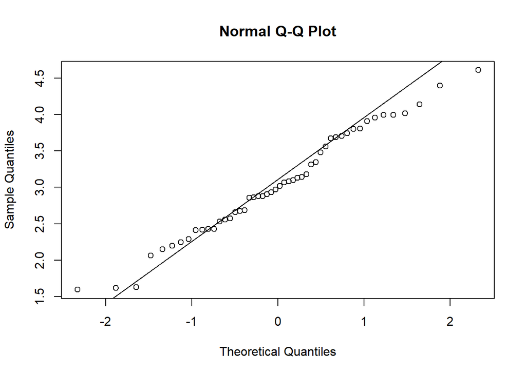

```
## Call: psych::mardia(x = c_sat_50)
##
## Mardia tests of multivariate skew and kurtosis
## Use describe(x) the to get univariate tests
## n.obs = 50   num.vars =  10
## b1p =  25.88   skew =  215.65  with probability =  0.57
##  small sample skew =  231.06  with probability =  0.29
## b2p =  115.85   kurtosis =  -0.95  with probability =  0.34
```

```r
c_sat_model <- 'F1 =~ CS1 + CS2 + CS3 + CS4
F2 =~ CS5 + CS6 + CS7
F3 =~ CS8 + CS9 + CS10'
c_sat_50 <- file003[1:50, ]


# Mardia's test for multivarite normality
psych::mardia(c_sat_50)
```

```r
# Fit model to the data using robust standard errors
c_sat_cfa_mlr <- cfa(model=c_sat_model, data=c_sat_50, estimator="MLR")

# Summary including standardized estimates and fit measures
summary(c_sat_cfa_mlr, fit.measures=TRUE, standardized=TRUE)
```

```
## lavaan 0.6-5 ended normally after 38 iterations
##
##   Estimator                                         ML
##   Optimization method                           NLMINB
##   Number of free parameters                         23
##
##   Number of observations                            50
##
## Model Test User Model:
##                                               Standard      Robust
##   Test Statistic                                39.842      41.892
##   Degrees of freedom                                32          32
##   P-value (Chi-square)                           0.161       0.113
##   Scaling correction factor                                  0.951
##     for the Yuan-Bentler correction (Mplus variant)
##
## Model Test Baseline Model:
##
##   Test statistic                               210.069     207.374
##   Degrees of freedom                                45          45
##   P-value                                        0.000       0.000
##   Scaling correction factor                                  1.013
##
## User Model versus Baseline Model:
##
##   Comparative Fit Index (CFI)                    0.952       0.939
##   Tucker-Lewis Index (TLI)                       0.933       0.914
##
##   Robust Comparative Fit Index (CFI)                         0.943
##   Robust Tucker-Lewis Index (TLI)                            0.920
##
## Loglikelihood and Information Criteria:
##
##   Loglikelihood user model (H0)               -477.184    -477.184
##   Scaling correction factor                                  1.082
##       for the MLR correction
##   Loglikelihood unrestricted model (H1)       -457.264    -457.264
##   Scaling correction factor                                  1.006
##       for the MLR correction
##
```

[output cut: 49 more lines]

```
## Variances:
##                    Estimate  Std.Err  z-value  P(>|z|)   Std.lv  Std.all
##    .CS1               0.363    0.100    3.616    0.000    0.363    0.637
##    .CS2               0.483    0.120    4.027    0.000    0.483    0.870
##    .CS3               0.292    0.078    3.752    0.000    0.292    0.493
##    .CS4               0.074    0.059    1.271    0.204    0.074    0.146
##    .CS5               0.211    0.065    3.225    0.001    0.211    0.586
##    .CS6               0.204    0.055    3.684    0.000    0.204    0.457
##    .CS7               0.431    0.128    3.361    0.001    0.431    0.599
##    .CS8               0.100    0.062    1.630    0.103    0.100    0.171
##    .CS9               0.321    0.082    3.893    0.000    0.321    0.460
##    .CS10              0.272    0.064    4.257    0.000    0.272    0.445
##     F1                0.207    0.112    1.851    0.064    1.000    1.000
##     F2                0.149    0.091    1.630    0.103    1.000    1.000
##     F3                0.487    0.154    3.171    0.002    1.000    1.000
```

```r
c_sat_model_a <- 'F1 =~ CS1 + CS2 + CS3 + CS4
F2 =~ CS5 + CS6 + CS7
F3 =~ CS8 + CS9 + CS10'
c_sat_model_b <- 'F1 =~ CS1 + CS3 + CS5 + CS7 + CS9
F2 =~ CS2 + CS4 + CS6 + CS8 + CS10'


# Fit the models to the data
c_sat_cfa_a <- cfa(model = c_sat_model_a, data = file003)
c_sat_cfa_b <- cfa(model = c_sat_model_b, data = file003)
# Print the model definitions
cat(c_sat_model_a)
```

```
## F1 =~ CS1 + CS2 + CS3 + CS4
## F2 =~ CS5 + CS6 + CS7
## F3 =~ CS8 + CS9 + CS10
```

```r
cat(c_sat_model_b)
```

```
## F1 =~ CS1 + CS3 + CS5 + CS7 + CS9
## F2 =~ CS2 + CS4 + CS6 + CS8 + CS10
```

```r
# Calculate the desired model fit statistics
fitMeasures(c_sat_cfa_a, fit.measures=c("cfi", "tli"))
```

```
##   cfi   tli
## 0.962 0.947
```

```r
fitMeasures(c_sat_cfa_b, fit.measures=c("cfi", "tli"))
```

```
##   cfi   tli
## 0.731 0.644
```

```r
c_sat <- file003
names(c_sat) <- c("CSU1", "CSU2", "CSU3", "CSU4", "EU1", "EU2", "EU3", "PS1", "PS2", "PS3")


# Add EU1 to the CSU factor
c_sat_model_a <- 'CSU =~ CSU1 + CSU2 + CSU3 + CSU4
                EU =~ EU1 + EU2 + EU3
                PS =~ PS1 + PS2 + PS3'

# View current c_sat model
cat(c_sat_model_a)
```

```
## CSU =~ CSU1 + CSU2 + CSU3 + CSU4
##                 EU =~ EU1 + EU2 + EU3
##                 PS =~ PS1 + PS2 + PS3
```

```r
# Add EU1 to the CSU factor
c_sat_model_b <- 'CSU =~ CSU1 + CSU2 + CSU3 + CSU4 + EU1
                EU =~ EU1 + EU2 + EU3
                PS =~ PS1 + PS2 + PS3'

# Fit Models A and B to the data
c_sat_cfa_a <- cfa(model = c_sat_model_a, data = c_sat)
c_sat_cfa_b <- cfa(model = c_sat_model_b, data = c_sat)

# Compare the nested models
anova(c_sat_cfa_a, c_sat_cfa_b)
```

```
## Chi-Squared Difference Test
##
##             Df    AIC    BIC  Chisq Chisq diff Df diff Pr(>Chisq)
## c_sat_cfa_b 31 7414.6 7507.2 64.521
## c_sat_cfa_a 32 7418.2 7506.9 70.057     5.5367       1    0.01862 *
## ---
## Signif. codes:  0 '***' 0.001 '**' 0.01 '*' 0.05 '.' 0.1 ' ' 1
```

```r
# Fit the model to the data
# c_sat_cfa <- cfa(model = c_sat_model, data = c_sat_group, group = "COUNTRY")

# Summarize results -- include fit measures and standardized estimates
# summary(c_sat_cfa, fit.measures=TRUE, standardized=TRUE)

# Get average estimate for both groups
# standardized_solution <- standardizedSolution(c_sat_cfa)
# standardized_solution %>%
#   filter(op == "=~") %>%
#   group_by(group) %>%
#   summarize(mean(est.std))


c_sat_cfa_model_3 <- 'F1 =~ CS1 + CS2 + CS3 + CS4
F2 =~ CS5 + CS6 + CS7
F3 =~ CS8 + CS9 + CS10'
c_sat_cfa_model_2 <- 'F1 =~ CS1 + CS2 + CS3 + CS4 + CS5 + CS6 + CS7
F2 =~ CS8 + CS9 + CS10'

# Fit three-factor CFA
c_sat_cfa_3 <- cfa(model = c_sat_cfa_model_3, data = file003)

# Inspect key fit measures - three-factor CFA
fitMeasures(c_sat_cfa_3, fit.measures = c("cfi","tli","rmsea"))
```

```
##   cfi   tli rmsea
## 0.962 0.947 0.058
```

```r
# Fit two-factor CFA
c_sat_cfa_2 <- cfa(model = c_sat_cfa_model_2, data = file003)

# Inspect key fit measures - two-factor CFA
fitMeasures(c_sat_cfa_2, fit.measures = c("cfi","tli","rmsea"))
```

```
##   cfi   tli rmsea
## 0.896 0.862 0.094
```

```r
# Compare measures of construct validity for three- versus two-factor models
semTools::reliability(c_sat_cfa_3)
```

```
##               F1        F2        F3     total
## alpha  0.7787792 0.6893959 0.7757958 0.8144735
## omega  0.7788456 0.6896567 0.7757469 0.8624756
## omega2 0.7788456 0.6896567 0.7757469 0.8624756
## omega3 0.7761082 0.6873162 0.7744738 0.8726313
## avevar 0.4701398 0.4276675 0.5362808 0.4788113
```

```r
semTools::reliability(c_sat_cfa_2)
```

```
##               F1        F2     total
## alpha  0.7944422 0.7757958 0.8144735
## omega  0.7953788 0.7757974 0.8450807
## omega2 0.7953788 0.7757974 0.8450807
## omega3 0.7894388 0.7745791 0.8476747
## avevar 0.3634437 0.5363521 0.4179396
```

```r
brand_rep_CFA_model <- 'F1 =~ well_made + consistent + poor_workman_r
F2 =~ higher_price + lot_more + go_up
F3 =~ stands_out + unique'
brand_rep_CFA <- lavaan::cfa(model=brand_rep_8_model, data=brand_rep_8)


# Print CFA model
cat(brand_rep_CFA_model)
```

```
## F1 =~ well_made + consistent + poor_workman_r
## F2 =~ higher_price + lot_more + go_up
## F3 =~ stands_out + unique
```

```r
# semTools reliability measures
semTools::reliability(brand_rep_CFA)
```

```
##               F1        F2        F3     total
## alpha  0.8926349 0.8521873 0.9514719 0.8464602
## omega  0.9017514 0.8605751 0.9520117 0.9340331
## omega2 0.9017514 0.8605751 0.9520117 0.9340331
## omega3 0.9019287 0.8646975 0.9520114 0.9196098
## avevar 0.7573092 0.6756174 0.9084654 0.7495705
```

```r
# psych standardized coefficient alpha measure
psych::alpha(brand_rep_9)$total$std.alpha
```

```
## [1] 0.8648896
```

```r
# Store F1 estimates as object loadings
loadings <- standardizedSolution(c_sat_cfa_3) %>%
    filter(op == "=~", lhs == "F1") %>%
    select(est.std)

# Composite reliability
re <- 1 - loadings ^ 2
result <- sum(loadings) ^ 2 / ((sum(loadings)^ 2)  + sum(re))
result
```

```
## [1] 0.7797144
```

```r
# Average variance extracted
l2 <- loadings ^ 2
avg_var <- sum(l2) / nrow(loadings)
avg_var
```

```
## [1] 0.4709497
```

```r
# Compare versus semTools
semTools::reliability(c_sat_cfa_3)
```

```
##               F1        F2        F3     total
## alpha  0.7787792 0.6893959 0.7757958 0.8144735
## omega  0.7788456 0.6896567 0.7757469 0.8624756
## omega2 0.7788456 0.6896567 0.7757469 0.8624756
## omega3 0.7761082 0.6873162 0.7744738 0.8726313
## avevar 0.4701398 0.4276675 0.5362808 0.4788113
```

```r
# Print brand_rep_factors
# brand_rep_factors

# Build model for lavaan
brand_rep_8_cfa_model <- "QUAL =~ consistent + well_made + poor_workman_r
PRICE =~ go_up + lot_more + higher_price
UNIQUE =~ stands_out + unique"

# Summarize results with fit measures and standardized estimates
# summary(brand_rep_8_CFA, standardized = TRUE, fit.measures = TRUE)

# Construct validity
# semTools::reliability(brand_rep_8_CFA)
```

Chapter 4 - Criterion Validity and Replication

Concurrent Validity and Model Diagrams:

- Criterion validity is a measure of relationship between the construct and external variable of interest
- Variables are not always on the 1-5 scale, and differences in units can negatively impact model validity
  - describe(myData) # check means and standard deviations (ideally, everything is N(0, 1)
- Can latentize a variable by adding it with =~
  - myModel <- ‘… age_fact =~ age’ # latentizes age to age_fact
- Can correlate manifest and latent variable with ~~
  - myModel <- ‘… age_fact =~ ageage_fact ~~ F1 + F2 + F3’ # latentizes age to age_fact and gets latent statistics (F1, F2, F3 already defined in the model)
  - mySEM <- sem(myModel, data=myData, estimator=“MLR”)
  - summary(mySEM, fit.measures=TRUE, standardized=TRUE)
- Diagrams are sometimes called “spaghetti and meatballs”, representing that they can be busy diagrams

Predictive Validity and Factor Scores:

- Predictive validity assesses the degree to which models predict future outcomes
- Linear regression can be used for this task
  - Begin by binding and scaling all of the relevant variables
- Can run regression in lavaan using ~
  - c_sat_model = “… spend ~ F1 + F2 + F3” # assumes F1, F2, F3 each defined as usual using =~
  - semPaths(c_sat_sem, rotation=2)
  - standardizedSolution(c_sat_sem) %>% filter(op == “~”) %>% mutate_if(is.numeric, round, digits=3)
  - inspect(c_sat_rem, “r2”) # pull the R-squared
- Factors scores are numerical scores reflecting relative standings on the latent factor
  - csat_cfa <- cfa(model = csat_model, data = c_sat)
  - csat_scores <- as.data.frame(predict(csat_cfa))
  - describe(csat_scores)
  - multi.hist(csat_scores)

Repeated Measures, Replication, and Factor Scores:

- Stability is a third form of reliability measurement
  - Does an instrument get similar responses if measuring the same population near the same time?
  - “Test-retest reliability”
  - survey_test_retest <- testRetest(t1 = survey_t_1, t2 = survey_t_2, id = “id”)
  - Generally, scores of 0.9+ are very good and scores of 0.7- are unreliable
- Replication is a different step that can be taken in the event that it is not possible to get people to retake the survey
  - Split the data by rows - odd vs. even

Wrap Up:

- Six step process for building and testing models

Example code includes:

```r
spendData <- c(94.5, 715, 145.5, 772.5, 133.5, 350, 75.5, 304.5, 117, 81, 234.5, 102, 152.5, 295, 145, 222, 121.5, 142, 82.5, 144, 130, 141, 545, 142.5, 175, 154, 130, 148.5, 255, 139.5, 420, 373.5, 197.5, 487.5, 337.5, 133.5, 114, 84, 255.5, 129, 114, 275, 297, 84, 87, 109.5, 123, 405, 123, 158, 145, 139.5, 112.5, 458, 138, 91.5, 190, 257.5, 155, 259, 120, 84, 84, 755, 84, 412, 270, 134, 285, 227.5, 133.5, 123, 127.5, 825, 418, 103.5, 144, 124, 120, 445.5, 150.5, 75, 129, 312, 330, 182.5, 282, 91.5, 218, 245, 157.5, 118.5, 148.5, 505, 87, 182, 111, 294, 110, 325.5, 115.5, 312, 120, 510, 91.5, 139.5, 85.5, 189, 152, 141, 138, 387, 114, 84, 213, 120, 115.5, 231, 78, 85.5, 354, 142.5, 128, 212, 547.5, 145, 103.5, 294, 354, 182.5, 185, 212, 97.5, 103.5, 235, 395, 105.5, 283.5, 155, 91.5, 94.5, 297.5, 283.5, 125, 159, 139.5, 95, 198, 104, 138, 155, 200, 97.5, 224, 588, 108, 100.5, 183, 350, 153, 150, 155, 91.5, 138, 117, 135.5, 138, 202, 257, 103.5, 114, 282, 112, 198, 159, 420, 315, 402, 507, 259.5, 81, 127.5, 144, 225, 141, 84, 150, 150.5, 455, 75, 294, 102, 199.5, 385, 155, 144, 135, 142.5, 172, 390, 94.5, 153, 472.5, 105, 123, 188, 325, 504, 99, 111, 151.5, 78, 545, 170, 123, 93, 381.5, 735, 100.5, 97.5, 155, 252.5, 192, 132, 252.5, 121.5, 90, 257, 151.5, 94.5, 153.5, 311.5, 79.5, 284, 151.5, 95, 78, 480, 102, 215, 115.5, 330, 592.5, 79.5, 355.5, 195, 105.5, 142.5, 154, 155, 312, 321, 75.5, 185, 324, 155, 530, 127.5, 148.5, 152, 111, 157.5, 151.5, 772.5, 123, 115.5, 145.5, 84, 515, 82.5, 108, 130.5, 138, 279, 151.5, 207, 150, 109.5, 150, 153.5, 152.5, 150.5, 88.5, 185, 115.5, 123, 150, 114, 321, 144, 142.5, 152, 82.5, 187.5, 97.5, 145, 257, 435, 250, 310.5, 78, 105.5, 102, 138, 303, 285, 155, 124.5, 240, 204, 118.5, 241.5, 147, 118.5, 105, 591.5, 180, 93, 252, 103.5, 287, 575, 75, 238, 189, 204, 210, 153, 145.5, 117, 559, 153.5, 79.5, 222.5, 145.5, 88.5, 159, 155, 255, 127.5, 300, 154, 213, 135, 84, 151.5, 127.5, 99, 200, 135, 522.5, 297, 152, 127.5, 203, 103.5, 178.5, 130.5, 255, 100.5, 213, 185, 228, 115.5, 109.5, 75.5, 273, 511, 414, 152, 217, 150, 102, 537.5, 282, 440, 288, 172.5, 112.5, 577.5, 140, 291.5, 152, 582.5, 210, 318.5, 185, 145.5, 148.5, 324, 145, 105.5, 132, 85.5, 135, 152, 135, 324, 200, 155, 247.5, 197.5, 95, 304.5, 215, 577.5, 111, 495, 141, 139.5, 112.5, 110, 135.5, 97.5, 157.5, 243, 159, 155, 185, 155, 114, 395, 130.5, 238, 345.5, 597.5, 210, 220, 210, 222.5, 124.5, 158, 150, 490.5, 270, 88.5, 205, 135, 90, 152, 309, 153, 105, 111, 78, 123, 159, 95, 115, 435, 235, 292.5, 155, 304.5, 114, 104, 135, 397.5, 93, 257, 102, 204, 252, 152, 215, 108, 148.5, 79.5, 155, 114, 94.5, 118.5, 178.5, 111, 150.5, 195, 85.5, 84, 93, 575, 148.5, 757.5, 155, 87, 112.5, 88.5, 255, 358, 84, 405, 153, 127.5, 81, 135.5, 154.5, 247.5, 182, 79.5, 373.5, 95, 147, 145.5, 152.5, 294, 259.5, 354, 103.5, 187.5, 124.5, 218, 227.5, 481.5, 125, 123, 450, 129, 318, 170, 319.5, 91.5, 183, 154, 391.5, 458, 303, 114, 111, 112.5, 222, 742.5, 234, 120, 81, 312, 335, 135, 133.5, 118.5, 390, 518, 215, 373.5, 118.5, 195, 111, 205, 94.5, 123, 99, 75.5, 102, 244, 380, 357.5, 254, 227.5, 198, 192.5, 151.5)
brand_rep_spend <- tibble::tibble(spend=spendData)
brand_rep <- file001 %>%
    mutate(poorworkman = 6-poor_workman_r) %>%
    select(-poorworkman)
brand_rep
```

```
## # A tibble: 559 x 9
##    well_made consistent poor_workman_r higher_price lot_more go_up stands_out
##        <dbl>      <dbl>          <dbl>        <dbl>    <dbl> <dbl>      <dbl>
##  1         1          1              1            1        1     1          1
##  2         1          1              2            3        5     5          1
##  3         1          1              1            2        2     2          2
##  4         5          3              5            5        5     5          5
##  5         1          1              1            1        1     1          1
##  6         1          1              1            4        5     5          1
##  7         1          1              1            1        3     1          1
##  8         1          1              1            3        3     3          3
##  9         1          1              1            1        1     2          2
## 10         1          1              1            1        5     5          1
## # ... with 549 more rows, and 2 more variables: unique <dbl>,
## #   one_of_a_kind <dbl>
```

```r
brand_rep_spend
```

```
## # A tibble: 559 x 1
##    spend
##    <dbl>
##  1  94.5
##  2 715
##  3 146.
##  4 772.
##  5 134.
##  6 350
##  7  75.5
##  8 304.
##  9 117
## 10  81
## # ... with 549 more rows
```

```r
# Check if brand_rep and brand_rep_spend have the same number of rows
same_rows <- nrow(brand_rep) == nrow(brand_rep_spend)
same_rows
```

```
## [1] TRUE
```

```r
# Append spend column to brand_rep
brand_rep <- cbind(brand_rep, brand_rep_spend)

# Scale the data
brand_rep_scaled <- scale(brand_rep)

# Get summary statistics of scaled dataframe
psych::describe(brand_rep)
```

```
##                vars   n   mean     sd median trimmed   mad min max range  skew
## well_made         1 559   1.49   0.83      1    1.31  0.00   1   5     4  2.22
## consistent        2 559   1.47   0.85      1    1.28  0.00   1   5     4  2.28
## poor_workman_r    3 559   1.36   0.77      1    1.18  0.00   1   5     4  2.77
## higher_price      4 559   2.48   1.36      2    2.35  1.48   1   5     4  0.54
## lot_more          5 559   3.41   1.48      4    3.51  1.48   1   5     4 -0.34
## go_up             6 559   3.14   1.45      3    3.18  1.48   1   5     4 -0.11
## stands_out        7 559   2.03   1.18      2    1.84  1.48   1   5     4  1.08
## unique            8 559   1.98   1.18      2    1.78  1.48   1   5     4  1.16
## one_of_a_kind     9 559   1.72   1.17      1    1.45  0.00   1   5     4  1.70
## spend            10 559 206.13 134.90    152  181.24 74.13  75 825   750  1.85
##                kurtosis   se
## well_made          5.63 0.04
## consistent         5.57 0.04
## poor_workman_r     8.59 0.03
## higher_price      -0.93 0.06
## lot_more          -1.35 0.06
## go_up             -1.35 0.06
## stands_out         0.30 0.05
## unique             0.43 0.05
## one_of_a_kind      1.92 0.05
## spend              3.61 5.71
```

```r
psych::describe(brand_rep_scaled)
```

```
##                vars   n mean sd median trimmed  mad   min  max range  skew
## well_made         1 559    0  1  -0.59   -0.21 0.00 -0.59 4.22  4.81  2.22
## consistent        2 559    0  1  -0.56   -0.23 0.00 -0.56 4.16  4.72  2.28
## poor_workman_r    3 559    0  1  -0.46   -0.23 0.00 -0.46 4.70  5.16  2.77
## higher_price      4 559    0  1  -0.35   -0.09 1.09 -1.09 1.85  2.93  0.54
## lot_more          5 559    0  1   0.40    0.07 1.00 -1.62 1.07  2.69 -0.34
## go_up             6 559    0  1  -0.10    0.02 1.02 -1.47 1.28  2.75 -0.11
## stands_out        7 559    0  1  -0.03   -0.16 1.26 -0.87 2.52  3.40  1.08
## unique            8 559    0  1   0.02   -0.17 1.26 -0.83 2.56  3.39  1.16
## one_of_a_kind     9 559    0  1  -0.62   -0.23 0.00 -0.62 2.81  3.43  1.70
## spend            10 559    0  1  -0.40   -0.18 0.55 -0.97 4.59  5.56  1.85
##                kurtosis   se
## well_made          5.63 0.04
## consistent         5.57 0.04
## poor_workman_r     8.59 0.04
## higher_price      -0.93 0.04
## lot_more          -1.35 0.04
## go_up             -1.35 0.04
## stands_out         0.30 0.04
## unique             0.43 0.04
## one_of_a_kind      1.92 0.04
## spend              3.61 0.04
```

```r
# Correlate F1, F2 and F3 to spend_f, the 'latentized' spend
brand_rep_model <- 'F1 =~ well_made + consistent + poor_workman_r
F2 =~ higher_price + lot_more + go_up
F3 =~ stands_out + unique
spend_f =~ spend
spend_f ~~ F1 + F2 + F3'

# Fit the model to the data -- sem()
brand_rep_cv <- lavaan::sem(data = brand_rep_scaled, model = brand_rep_model)

# Print the standardized covariances b/w spend_f and other factors
lavaan::standardizedSolution(brand_rep_cv) %>%
    filter(rhs == "spend_f")
```

```
##       lhs op     rhs   est.std         se        z pvalue  ci.lower  ci.upper
## 1      F1 ~~ spend_f 0.4188200 0.03650946 11.47155      0 0.3472628 0.4903772
## 2      F2 ~~ spend_f 0.4544334 0.03649017 12.45358      0 0.3829139 0.5259528
## 3      F3 ~~ spend_f 0.4360441 0.03504776 12.44142      0 0.3673517 0.5047364
## 4 spend_f ~~ spend_f 1.0000000 0.00000000       NA     NA 1.0000000 1.0000000
```

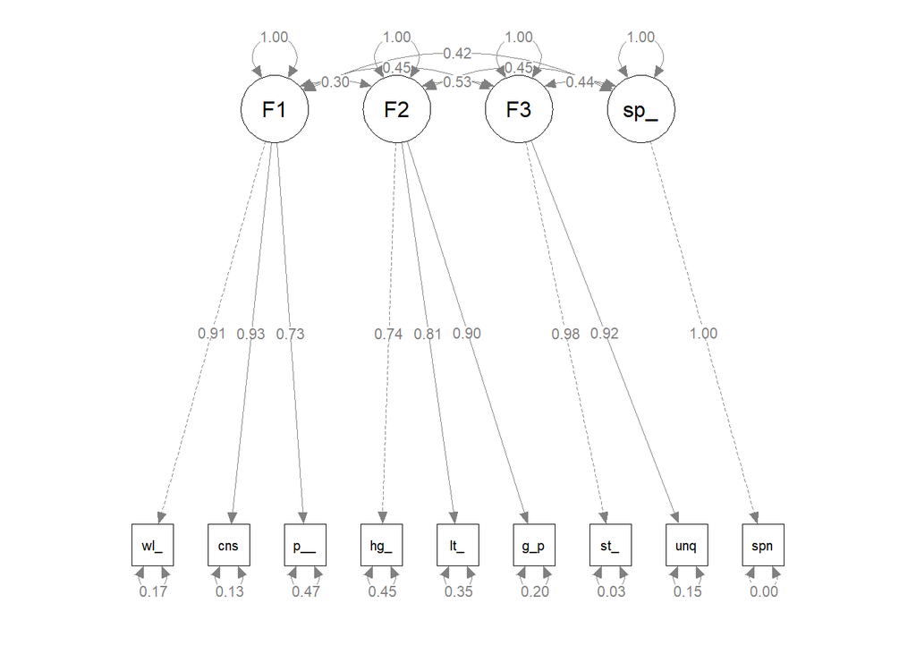

```r
# Plot the model with standardized estimate labels
semPlot::semPaths(brand_rep_cv, whatLabels = "est.std", edge.label.cex = .8)
```

```r
c_sat <- file003
c_sat_recommend <- tibble::tibble(Rec_1=c(4, 3, 3, 3, 4, 3, 2, 3, 3, 3, 4, 3, 3, 4, 4, 3, 3, 4, 4, 3, 4, 4, 3, 4, 4, 3, 3, 3, 3, 3, 4, 3, 4, 4, 3, 2, 3, 3, 3, 4, 4, 3, 4, 4, 5, 3, 4, 4, 4, 2, 3, 3, 3, 3, 3, 3, 3, 4, 4, 4, 2, 3, 3, 4, 4, 3, 4, 3, 3, 4, 3, 3, 3, 1, 3, 4, 4, 3, 3, 3, 3, 3, 3, 4, 4, 2, 4, 4, 4, 3, 3, 4, 3, 3, 3, 4, 3, 3, 3, 3, 4, 2, 4, 3, 4, 3, 3, 4, 3, 2, 3, 2, 3, 3, 4, 3, 4, 2, 3, 3, 2, 4, 3, 4, 2, 3, 4, 3, 3, 3, 4, 4, 4, 3, 3, 4, 3, 3, 4, 4, 4, 3, 2, 3, 3, 4, 2, 5, 3, 4, 4, 4, 3, 3, 3, 3, 4, 3, 3, 3, 3, 4, 3, 4, 3, 4, 4, 3, 3, 3, 3, 3, 4, 4, 4, 4, 3, 4, 3, 3, 4, 4, 3, 3, 3, 3, 4, 2, 4, 3, 3, 3, 3, 4, 4, 4, 3, 3, 3, 2, 4, 4, 3, 3, 3, 4, 3, 3, 4, 4, 3, 3, 5, 4, 4, 3, 4, 2, 4, 4, 4, 4, 3, 4, 3, 3, 3, 2, 3, 3, 3, 4, 3, 3, 4, 5, 4, 4, 3, 4, 4, 3, 3, 4, 4, 3, 4, 3, 4, 4, 4, 1, 4, 3, 4, 3, 3, 3, 4, 3, 5, 4, 3, 3, 4, 3, 4, 3, 3, 3, 3, 4, 2, 3, 4, 3, 4, 3, 4, 4, 4, 3, 3, 3, 5, 3, 3, 4, 3, 3, 4, 4, 4, 4, 4, 3, 3, 4, 3, 3, 3, 4, 3, 3, 4, 2, 4, 3, 2, 3, 3, 5, 4, 2, 5, 3, 5, 3, 2, 3, 4, 4, 3, 3, 3, 3, 3, 3, 3, 3, 3, 4, 3, 3, 3, 3, 5, 4, 4, 3, 3, 5, 3, 4, 3, 5, 4, 3, 2, 2))
c_sat
```

```
## # A tibble: 350 x 10
##      CS1   CS2   CS3   CS4   CS5   CS6   CS7   CS8   CS9  CS10
##    <dbl> <dbl> <dbl> <dbl> <dbl> <dbl> <dbl> <dbl> <dbl> <dbl>
##  1     4     3     4     4     3     4     4     4     4     4
##  2     3     4     3     3     2     3     4     2     3     2
##  3     3     3     3     4     3     4     2     3     5     3
##  4     3     4     3     3     3     4     3     2     3     2
##  5     4     4     4     4     3     4     3     3     2     3
##  6     4     3     4     4     2     4     3     4     4     3
##  7     2     2     2     2     3     2     2     3     4     3
##  8     2     3     3     3     3     3     2     3     3     2
##  9     3     4     4     3     3     3     3     2     3     2
## 10     3     4     3     3     3     3     2     3     3     3
## # ... with 340 more rows
```

```r
c_sat_recommend
```

```
## # A tibble: 350 x 1
##    Rec_1
##    <dbl>
##  1     4
##  2     3
##  3     3
##  4     3
##  5     4
##  6     3
##  7     2
##  8     3
##  9     3
## 10     3
## # ... with 340 more rows
```

```r
# Bind & scale the variables
c_sat_rec_scale <- c_sat %>%
    bind_cols(c_sat_recommend) %>% scale()

# Define the model - Rec_f covaries with F1, F2, F3
c_sat_rec_model <- 'F1 =~ CS1 + CS2 + CS3 + CS4
F2 =~ CS5 + CS6 + CS7
F3 =~ CS8 + CS9 + CS10
Rec_f =~ Rec_1
Rec_f ~~ F1 + F2 + F3'

# Fit the model to the data
c_sat_rec_sem <- lavaan::sem(model = c_sat_rec_model, data = c_sat_rec_scale)

# Look up standardized covariances
lavaan::standardizedSolution(c_sat_rec_sem) %>%
    filter(rhs == "Rec_f")
```

```
##     lhs op   rhs   est.std         se         z      pvalue  ci.lower  ci.upper
## 1    F1 ~~ Rec_f 0.9488011 0.01584205 59.891319 0.00000e+00 0.9177512 0.9798509
## 2    F2 ~~ Rec_f 0.7827810 0.03311674 23.637021 0.00000e+00 0.7178734 0.8476886
## 3    F3 ~~ Rec_f 0.3749696 0.05284970  7.095019 1.29341e-12 0.2713861 0.4785531
## 4 Rec_f ~~ Rec_f 1.0000000 0.00000000        NA          NA 1.0000000 1.0000000
```

```r
# Define the model
b_q_model <- 'HIP =~ trendy + latest + tired_r
            VALUE =~ happy_pay + reason_price + good_deal
            PERFORM =~ strong_perform + leader + serious
            spend ~ HIP + VALUE + PERFORM'

# Fit the model to the data
# b_q_pv <- lavaan::sem(data = b_q_scale, model = b_q_model)

# Check fit, r-square, standardized estimates
# summary(b_q_pv, standardized = TRUE, fit.measures = TRUE, rsquare = TRUE)

# Plot the model -- rotate from left to right
# semPlot::semPaths(b_q_pv, rotation = 2, whatLabels = "est.std", edge.label.cex = 0.8)


# Plot the new model
# semPlot::semPaths(brand_rep_sem, rotation = 2)

# Get the coefficient information
# lavaan::standardizedSolution(brand_rep_sem) %>% filter(op == "~")

# Get the r-squared
# r_squared <- car::inspect(brand_rep_sem, "r2")["F2"]
# r_squared


# Compute factor scores in lavaan -- store as data frame
brand_rep_scores <- as.data.frame(predict(brand_rep_CFA))

# Summary statistics of our factor scores
psych::describe(brand_rep_scores)
```

```
##    vars   n mean   sd median trimmed  mad   min  max range  skew kurtosis   se
## F1    1 559    0 0.73  -0.41   -0.16 0.08 -0.46 3.33  3.79  2.31     6.18 0.03
## F2    2 559    0 0.94   0.00    0.01 1.17 -1.51 1.56  3.08 -0.06    -1.18 0.04
## F3    3 559    0 1.13  -0.05   -0.18 1.38 -1.03 2.98  4.01  1.09     0.35 0.05
```

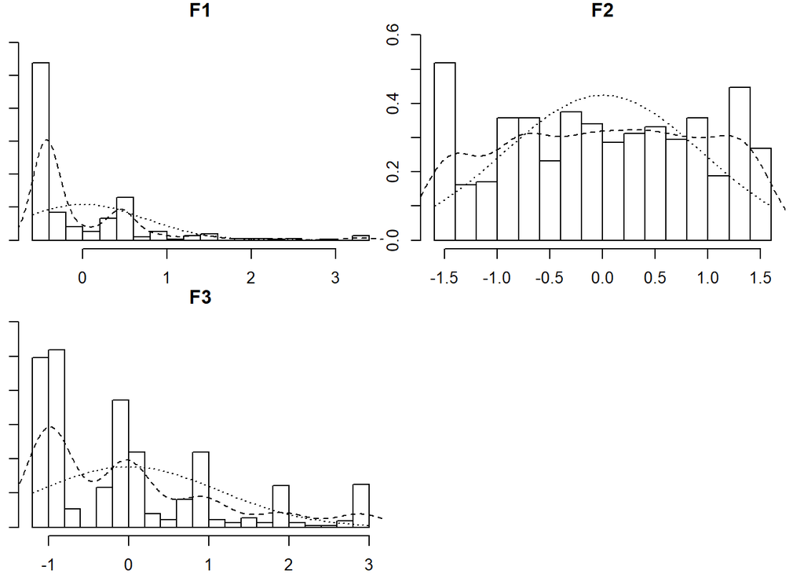

```r
# Plot histograms for each variable
psych::multi.hist(brand_rep_scores)
```

```r
# Are they normally distributed? Check using map()
map(brand_rep_scores, shapiro.test)
```

```
## $F1
##
##  Shapiro-Wilk normality test
##
## data:  .x[[i]]
## W = 0.66866, p-value < 2.2e-16
##
##
## $F2
##
##  Shapiro-Wilk normality test
##
## data:  .x[[i]]
## W = 0.94835, p-value = 4.654e-13
##
##
## $F3
##
##  Shapiro-Wilk normality test
##
## data:  .x[[i]]
## W = 0.82771, p-value < 2.2e-16
```

```r
# Linear regression of standardized spending and factor scores
# bq_fs_reg <- lm(spend ~ F1 + F2 + F3, data = bq_fs_spend)

# Summarize results, round estimates
# rounded_summary <- round(coef(bq_fs_reg), 3)
# rounded_summary

# Summarize the results of CFA model
# summary(brand_qual_pv)

# Compare the r-squared of each
# inspect_rsq <- car::inspect(brand_qual_pv, "r2")["spend"]
# inspect_rsq
# summary(bq_fs_reg)$r.squared


# Descriptive statistics grouped by 'time'
# psych::describeBy(brand_rep_t1_t2, "time")

# Test retest: time == 1 versus time == 2 by id = "id"
# brand_rep_test_retest <- psych::testRetest(t1 = filter(brand_rep_t1_t2, time == 1), t2 = filter(brand_rep_t1_t2, time == 2), id = "id")

# brand_rep_test_retest$r12


brand_rep <- file001 %>%
    select(-one_of_a_kind)
brand_rep
```

```
## # A tibble: 559 x 8
##    well_made consistent poor_workman_r higher_price lot_more go_up stands_out
##        <dbl>      <dbl>          <dbl>        <dbl>    <dbl> <dbl>      <dbl>
##  1         1          1              1            1        1     1          1
##  2         1          1              2            3        5     5          1
##  3         1          1              1            2        2     2          2
##  4         5          3              5            5        5     5          5
##  5         1          1              1            1        1     1          1
##  6         1          1              1            4        5     5          1
##  7         1          1              1            1        3     1          1
##  8         1          1              1            3        3     3          3
##  9         1          1              1            1        1     2          2
## 10         1          1              1            1        5     5          1
## # ... with 549 more rows, and 1 more variable: unique <dbl>
```

```r
# Split data into odd and even halves
brand_rep_efa_data <- as.data.frame(brand_rep)[c(TRUE,FALSE),]
brand_rep_cfa_data <- as.data.frame(brand_rep)[c(FALSE,TRUE),]

# Get factor loadings of brand_rep_efa_data EFA
efa <- psych::fa(brand_rep_efa_data, nfactors = 3)
efa$loadings
```

```
##
## Loadings:
##                MR1    MR2    MR3
## well_made       0.925
## consistent      0.953
## poor_workman_r  0.742
## higher_price    0.159  0.609  0.147
## lot_more               0.799
## go_up                  0.942
## stands_out                    1.006
## unique                        0.890
##
##                  MR1   MR2   MR3
## SS loadings    2.345 1.900 1.826
## Proportion Var 0.293 0.237 0.228
## Cumulative Var 0.293 0.531 0.759
```

```r
# Confirm the data that the model was fit to
# car::inspect(brand_rep_cfa, what = "call")

# Check fit measures
# fitmeasures(brand_rep_cfa)[c("cfi", "tli", "rmsea")]
```

### *R for SAS Users*

Chapter 1 - Getting Started with R

Get Help and Load Data in R:

- R Functionality includes packages and global environment
  - ls() is similar to PROC DATASETS
  - load() is similar to LIBNAME or DATA + SET
- Generally, an R session begins without any objects loaded in memory
- Abalone dataset is available from UC Irvine
  - load(“abalone.Rdata”)
  - library(myPkg) will load myPkg
  - sessionInfo() shows the currently loaded packages

Dataset Contents and Descriptive Statistics:

- Can use readr::read_csv() to load a CSV file in to the environment
  - myObject <- readr::read_csv(“myFile.csv”)
  - str(myObject) # look at the variables and dimensions of the dataset
  - dim(myObject) # dimensions of the object
  - names(myObject) # variable names
  - head(myObject) # first 6 rows
  - tail(myObject) # last 6 rows
- The dplyr functions are helpful for manipulating data frames
  - arrange(myDF, myCol) # sort by ascending myCol
  - myDF %>% arrange(myCol) # sort by ascending myCol (same as above)
  - myDF %>% pull(myCol) # extract myCol as a vector
  - myDF %>% pull(myCol) %>% mean() # extract myCol as a vector and take the mean()
  - myDF %>% select(a, b) %>% summary() # keep only columns “a” and “b”, then create a summary of that frame

Graphical Visualizations:

- The ggplot2 package is useful for plotting data in R
  - “grammar of graphics” - layering approach to graphics
  - Build a base layer and then add to it
  - ggplot(data=myDF, aes(x=x, y=y)) + geom_boxplot() + theme_bw() # build a boxplot of y by x using the bw theme
  - Can include options like color= or fill=
  - Can customize axes using xlab(), ylab(), and ggtitle()

Example code includes:

```r
# List the objects in global environment
# ls()

# Load the "abalone.RData" dataset
# load("abalone.RData")

# List objects in global environment again
# ls()

# Learn more about the load function
# help(load)

# Learn more about the ls function
# help(ls)


# Run sessionInfo() see packages available to this session
# sessionInfo()

# Load Hmisc package
# library(Hmisc)

# Run sessionInfo() again to see updated package list
# sessionInfo()


# Load abalone.csv dataset assign output to abalone
# abalone <- readr::read_csv("abalone.csv")

data(abalone, package = "AppliedPredictiveModeling")
abalone <- tibble::as_tibble(abalone)

# Get the dimensions of the abalone dataset object
dim(abalone)
```

```
## [1] 4177    9
```

```r
# Get variable names in the abalone dataset object
names(abalone)
```

```
## [1] "Type"          "LongestShell"  "Diameter"      "Height"
## [5] "WholeWeight"   "ShuckedWeight" "VisceraWeight" "ShellWeight"
## [9] "Rings"
```

```r
chgName <- function(x) {
    paste0(stringr::str_to_lower(stringr::str_sub(x, 1, 1)), stringr::str_sub(x, 2))
}

tmpNames <- sapply(names(abalone), FUN=chgName, USE.NAMES=FALSE)
names(abalone) <- tmpNames
names(abalone)
```

```
## [1] "type"          "longestShell"  "diameter"      "height"
## [5] "wholeWeight"   "shuckedWeight" "visceraWeight" "shellWeight"
## [9] "rings"
```

```r
# View top 3 rows of abalone dataset using head()
head(abalone, 3)
```

```
## # A tibble: 3 x 9
##   type  longestShell diameter height wholeWeight shuckedWeight visceraWeight
##   <fct>        <dbl>    <dbl>  <dbl>       <dbl>         <dbl>         <dbl>
## 1 M            0.455    0.365  0.095       0.514        0.224         0.101
## 2 M            0.35     0.265  0.09        0.226        0.0995        0.0485
## 3 F            0.53     0.42   0.135       0.677        0.256         0.142
## # ... with 2 more variables: shellWeight <dbl>, rings <int>
```

```r
# View bottom 3 rows of abalone dataset using tail()
tail(abalone, 3)
```

```
## # A tibble: 3 x 9
##   type  longestShell diameter height wholeWeight shuckedWeight visceraWeight
##   <fct>        <dbl>    <dbl>  <dbl>       <dbl>         <dbl>         <dbl>
## 1 M            0.6      0.475  0.205        1.18         0.526         0.288
## 2 F            0.625    0.485  0.15         1.09         0.531         0.261
## 3 M            0.71     0.555  0.195        1.95         0.946         0.376
## # ... with 2 more variables: shellWeight <dbl>, rings <int>
```

```r
# Run arrange function from dplyr to sort the data by rings
arrange(abalone, rings)
```

```
## # A tibble: 4,177 x 9
##    type  longestShell diameter height wholeWeight shuckedWeight visceraWeight
##    <fct>        <dbl>    <dbl>  <dbl>       <dbl>         <dbl>         <dbl>
##  1 I            0.075    0.055  0.01       0.002         0.001         0.0005
##  2 I            0.15     0.1    0.025      0.015         0.0045        0.004
##  3 I            0.13     0.1    0.03       0.013         0.0045        0.003
##  4 I            0.11     0.09   0.03       0.008         0.0025        0.002
##  5 I            0.165    0.12   0.03       0.0215        0.007         0.005
##  6 M            0.21     0.15   0.05       0.0385        0.0155        0.0085
##  7 M            0.155    0.11   0.04       0.0155        0.0065        0.003
##  8 I            0.16     0.11   0.025      0.018         0.0065        0.0055
##  9 I            0.24     0.175  0.065      0.0665        0.031         0.0135
## 10 I            0.195    0.15   0.045      0.0375        0.018         0.006
## # ... with 4,167 more rows, and 2 more variables: shellWeight <dbl>,
## #   rings <int>
```

```r
# Rewrite the line of code above using the %>% notation
abalone %>%
    arrange(rings)
```

```
## # A tibble: 4,177 x 9
##    type  longestShell diameter height wholeWeight shuckedWeight visceraWeight
##    <fct>        <dbl>    <dbl>  <dbl>       <dbl>         <dbl>         <dbl>
##  1 I            0.075    0.055  0.01       0.002         0.001         0.0005
##  2 I            0.15     0.1    0.025      0.015         0.0045        0.004
##  3 I            0.13     0.1    0.03       0.013         0.0045        0.003
##  4 I            0.11     0.09   0.03       0.008         0.0025        0.002
##  5 I            0.165    0.12   0.03       0.0215        0.007         0.005
##  6 M            0.21     0.15   0.05       0.0385        0.0155        0.0085
##  7 M            0.155    0.11   0.04       0.0155        0.0065        0.003
##  8 I            0.16     0.11   0.025      0.018         0.0065        0.0055
##  9 I            0.24     0.175  0.065      0.0665        0.031         0.0135
## 10 I            0.195    0.15   0.045      0.0375        0.018         0.006
## # ... with 4,167 more rows, and 2 more variables: shellWeight <dbl>,
## #   rings <int>
```

```r
# Find mean length of abalones using pull() and mean()
abalone %>%
    pull(longestShell) %>%
    mean()
```

```
## [1] 0.5239921
```

```r
# Find the median wholeWeight of the abalones
abalone %>%
    pull(wholeWeight) %>%
    median()
```

```
## [1] 0.7995
```

```r
# Get descriptive statistics of diameter and shellWeight
abalone %>%
    select(diameter, shellWeight) %>%
    summary()
```

```
##     diameter       shellWeight
##  Min.   :0.0550   Min.   :0.0015
##  1st Qu.:0.3500   1st Qu.:0.1300
##  Median :0.4250   Median :0.2340
##  Mean   :0.4079   Mean   :0.2388
##  3rd Qu.:0.4800   3rd Qu.:0.3290
##  Max.   :0.6500   Max.   :1.0050
```

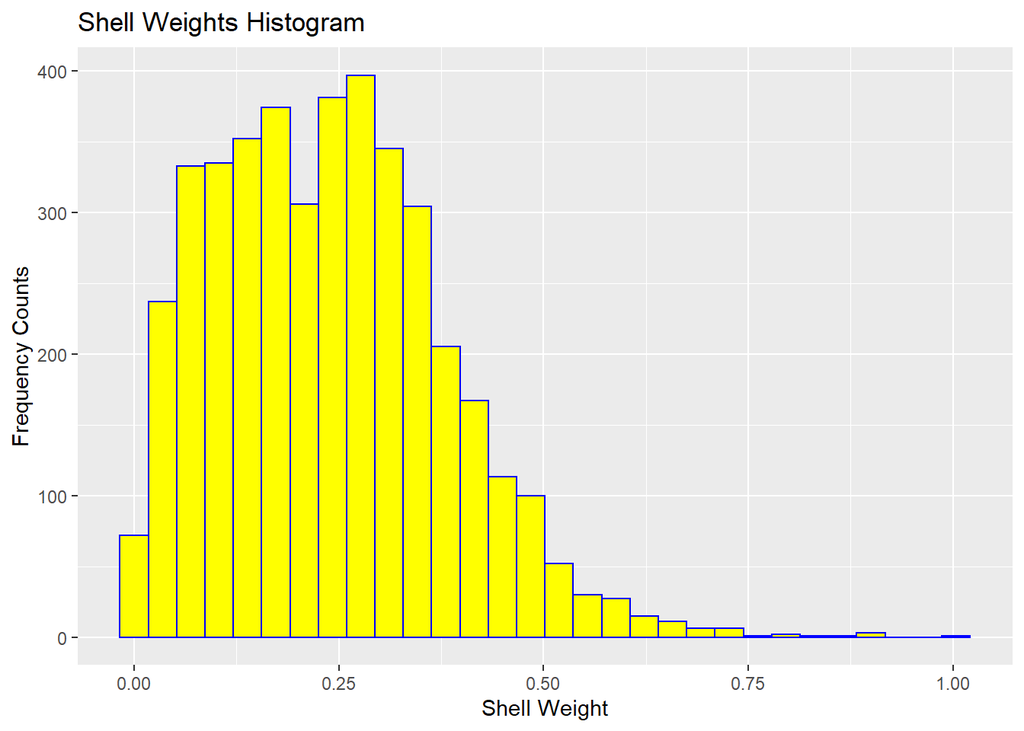

```r
# Add a title and labels for the axes
ggplot(abalone, aes(shellWeight)) +
    geom_histogram(color = "blue", fill = "yellow") +
    xlab("Shell Weight") +
    ylab("Frequency Counts") +
    ggtitle("Shell Weights Histogram")
```

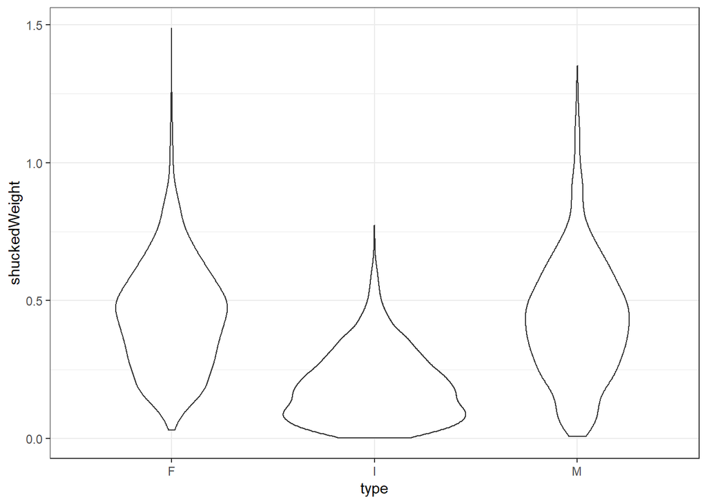

```r
# Change the boxplots to the violin geom
ggplot(data = abalone, aes(x=type, y=shuckedWeight)) +
    geom_violin() +
    theme_bw()
```

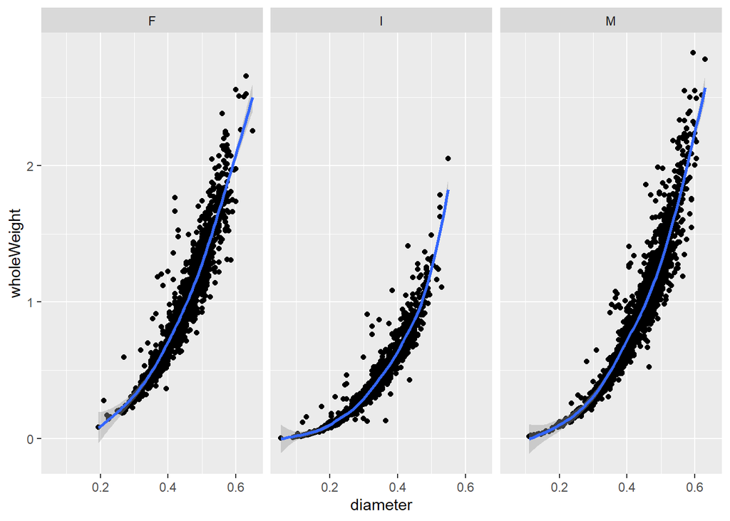

```r
# Create panel plot of scatterplot for sex categories
ggplot(abalone, aes(diameter, wholeWeight)) +
    geom_point() +
    geom_smooth() +
    facet_wrap(~type)
```

Chapter 2 - Data Wrangling

Objects - Building Blocks of R:

- Objects are the buidling blocks of R - “everything in R is an object”
  - The assignment operator is <-
  - The c() operator is the combine function, which can be used to create a vector
- Can create matrices using matrix() and data frames using data.frame()
- Can get the class of an objects using class() or see it as one of the outputs of str()

Selecting Elements from Objects:

- Can select elements from a matrix using myMtx[myRow, myCol] - if myRow is blank it means “all rows” and if myCol is blank it means “all columns”
  - Same approach for data frames, though names for columns can be used rather than numbers
- Can select variables using a:b, which will pull all variables from a through b
- Can grab rows using dplyr::slice()
  - slice(2:3) will pull rows 2 and 3

Manipulating Datasets and Data Objects:

- Can use the mutate() function to create new variables, similar to data a; set a; myVar=myOldVar/100; in SAS
- Can use the ifelse() function to create new variables based on a boolean condition
- Can use is.numeric(), is.vector(), is.character(), is.data.frame(), is.matrix()
- Can coerce object types to new types using as.xxx()
  - as.matrix()
  - as.numeric()
  - as.integer()

Data Quality and Cleaning:

- Can use the summary() function to check for minima, maxima, mean, median, etc.
- The geom_dotplot() can be helpful in identifying outliers
- Can filter out cases with errors, then resume the analysis

Example code includes:

```r
# Assign the value of 1 to an object x
x <- 1

# Create object w by adding the value 4 to x
w <- x + 4

# Create vector object y
y <- c(5, 2, 3)

# Create a vector z
z <- c("red", "green", "blue")

# Create a logical object v
v <- c(TRUE, TRUE, FALSE)


numvec1 <- 1:3
numvec2 <- c(5, 2, 3)
charvec <- c("red", "green", "blue")
logicvec <- c(TRUE, TRUE, FALSE)

# Create matrix with numvec1 and numvec2 with 2 columns, 3 rows
nummtx <- matrix(c(numvec1, numvec2), ncol=2, nrow=3)

# Create dataframe from numvec1, numvec2, charvec and logicvec
dataframe <- data.frame(numvec1, numvec2, charvec, logicvec)

# Get the structure of dataframe
str(dataframe)
```

```
## 'data.frame':    3 obs. of  4 variables:
##  $ numvec1 : int  1 2 3
##  $ numvec2 : num  5 2 3
##  $ charvec : Factor w/ 3 levels "blue","green",..: 3 2 1
##  $ logicvec: logi  TRUE TRUE FALSE
```

```r
# Select the 2nd element in vector charvec
charvec[2]
```

```
## [1] "green"
```

```r
# Select the 2nd column of matrix nummtx
nummtx[, 2]
```

```
## [1] 5 2 3
```

```r
# Pull column numvec1 from dataframe assign it to id
id <- dataframe %>%
    pull(numvec1)

# Pull column charvec from dataframe and determine the class of charvec
dataframe %>%
    pull(charvec) %>%
    class()
```

```
## [1] "factor"
```

```r
# Create abaloneMod from abalone, add new variable age
abaloneMod <- abalone %>%
    mutate(age = rings + 1.5)

# Add three more variables to abaloneMod
abaloneMod <- abaloneMod %>%
    mutate(pctShucked = shuckedWeight * 100 / wholeWeight) %>%
    mutate(pctViscera = visceraWeight * 100 / wholeWeight) %>%
    mutate(pctShell = shellWeight * 100 / wholeWeight)

# Select age, pctShucked, pctViscera, pctShell, run summary()
abaloneMod %>%
    select(age, pctShucked, pctViscera, pctShell) %>%
    summary()
```

```
##       age          pctShucked       pctViscera         pctShell
##  Min.   : 2.50   Min.   : 17.53   Min.   : 0.7634   Min.   : 10.93
##  1st Qu.: 9.50   1st Qu.: 39.51   1st Qu.:19.8586   1st Qu.: 26.61
##  Median :10.50   Median : 43.06   Median :21.7252   Median : 29.09
##  Mean   :11.43   Mean   : 43.24   Mean   :21.8537   Mean   : 29.56
##  3rd Qu.:12.50   3rd Qu.: 46.62   3rd Qu.:23.6945   3rd Qu.: 31.94
##  Max.   :30.50   Max.   :469.19   Max.   :66.5399   Max.   :261.57
```

```r
# Add new character variable agecat to abaloneMod
abaloneMod <- abaloneMod %>%
    mutate(agecat = factor(ifelse(test = age < 10.5, "< 10.5", "10.5 and older")))

# Add new logical variable adult to abaloneMod
abaloneMod <- abaloneMod %>%
    mutate(adult = (type != "I"))

# Select age, agecat, sex, adult and view top 6 rows
abaloneMod %>%
    select(age, agecat, type, adult) %>%
    head(6)
```

```
## # A tibble: 6 x 4
##     age agecat         type  adult
##   <dbl> <fct>          <fct> <lgl>
## 1  16.5 10.5 and older M     TRUE
## 2   8.5 < 10.5         M     TRUE
## 3  10.5 10.5 and older F     TRUE
## 4  11.5 10.5 and older M     TRUE
## 5   8.5 < 10.5         I     FALSE
## 6   9.5 < 10.5         I     FALSE
```

```r
# Convert adult to numeric and confirm class type
abaloneMod %>%
    mutate(adult = as.numeric(adult)) %>%
    pull(adult) %>%
    class()
```

```
## [1] "numeric"
```

```r
# Select three dimensions, save as abalonedim
abalonedim <- abaloneMod %>%
    select(longestShell, diameter, height)

# Convert abalonedim to a matrix and confirm class type
abalonedim %>%
    as.matrix() %>%
    class()
```

```
## [1] "matrix"
```

```r
# Pull height from abaloneMod and run summary()
abaloneMod %>%
    pull(height) %>%
    summary()
```

```
##    Min. 1st Qu.  Median    Mean 3rd Qu.    Max.
##  0.0000  0.1150  0.1400  0.1395  0.1650  1.1300
```

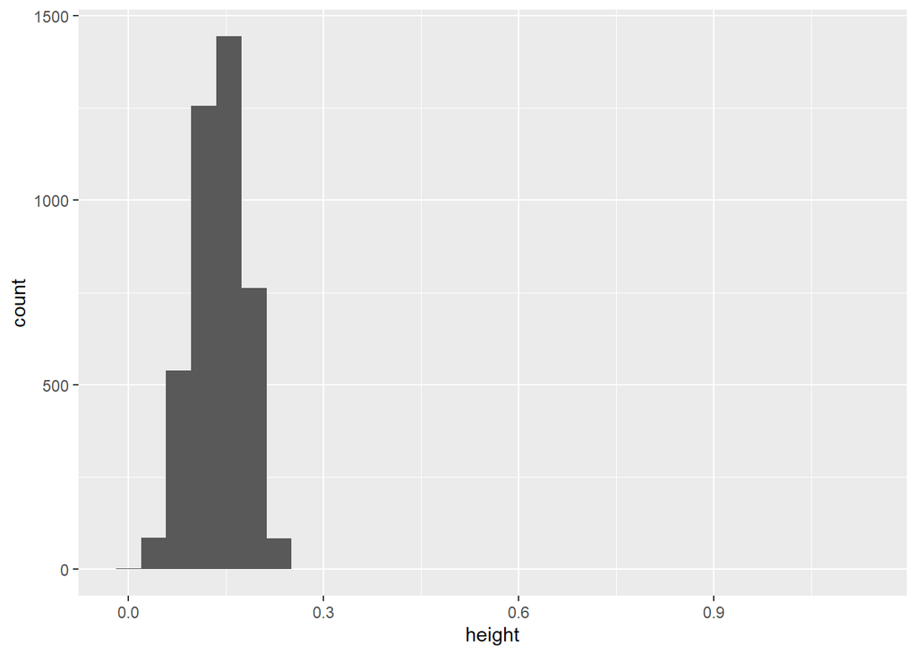

```r
# Keep cases with height > 0 assign to abaloneKeep
abaloneKeep <- abaloneMod %>%
    filter(height > 0)

# Make histogram of updated heights in abaloneKeep
ggplot(abaloneKeep, aes(x=height)) +
    geom_histogram()
```

```r
# Sort abaloneKeep by pctShucked, view largest 6 pctShucked
abaloneKeep %>%
    arrange(pctShucked) %>%
    pull(pctShucked) %>%
    tail(6)
```

```
## [1]  83.46457  96.23656 149.26471 153.99240 412.32227 469.19431
```

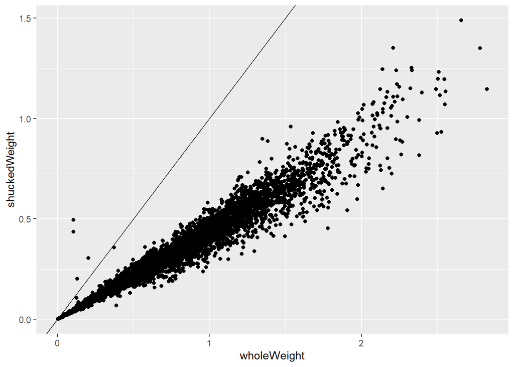

```r
# Scatterplot of shuckedWeight by wholeWeight add y=x line
ggplot(abaloneKeep, aes(x=wholeWeight, y=shuckedWeight)) +
    geom_point() +
    geom_abline(intercept=0, slope=1)
```

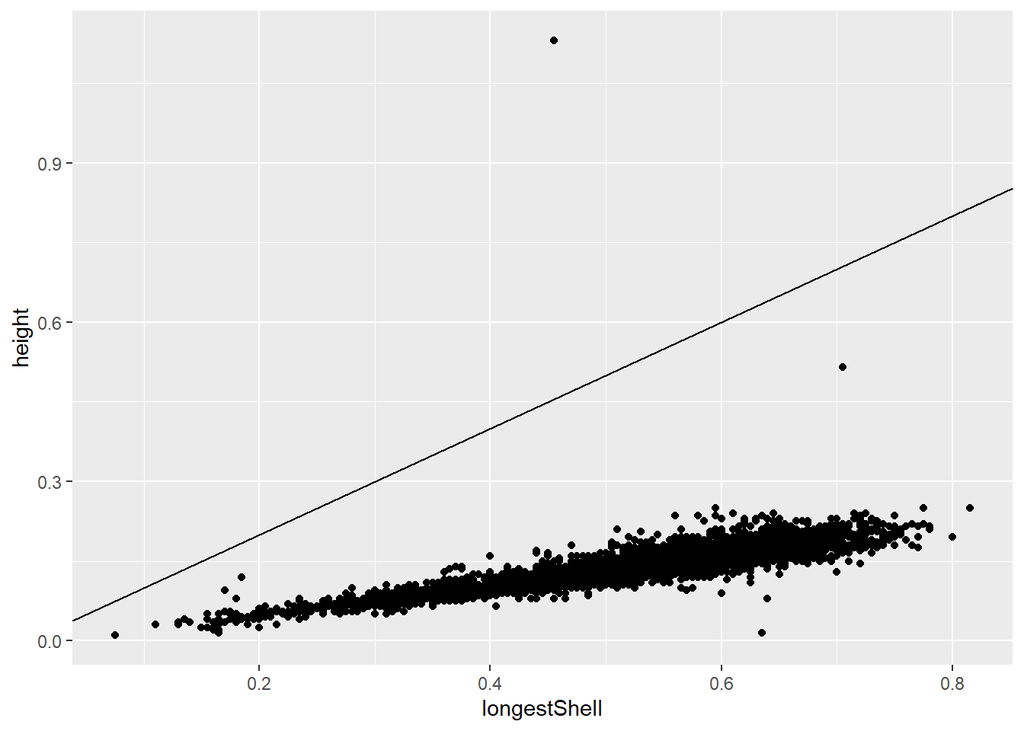

```r
# Keep cases where shuckedWeight is less than wholeWeight
abaloneKeep <- abaloneKeep %>%
    filter(shuckedWeight < wholeWeight)


# Make scatterplot of height by length add y=x line
ggplot(abaloneKeep, aes(x=longestShell, y=height)) +
    geom_point() +
    geom_abline(intercept=0, slope=1)
```

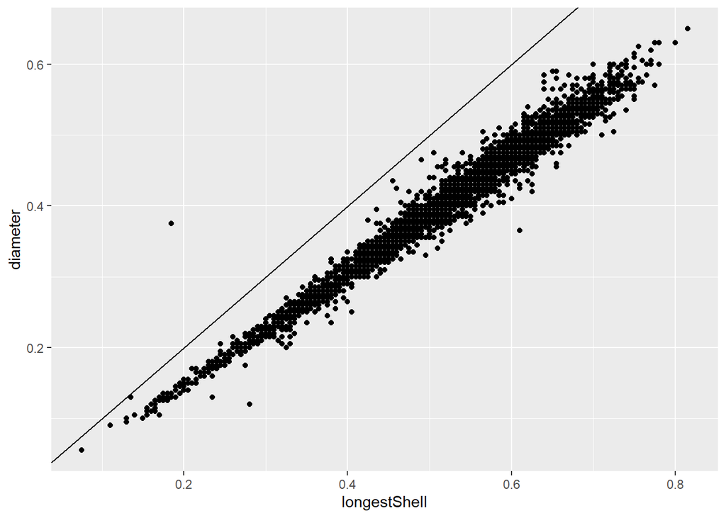

```r
# Make scatterplot of diameter by length add y=x line
ggplot(abaloneKeep, aes(x=longestShell, y=diameter)) +
    geom_point() +
    geom_abline(intercept=0, slope=1)
```

```r
# Keep abalones with length > both height and diameter
abaloneKeep <- abaloneKeep %>%
    filter((longestShell > height) & (longestShell > diameter))


# Dimensions of final dataset with samples in abaloneKeep
dim(abaloneKeep)
```

```
## [1] 4169   15
```

```r
# Get summary statistics of all variables in abaloneKeep
summary(abaloneKeep)
```

```
##  type      longestShell       diameter          height        wholeWeight
##  F:1306   Min.   :0.0750   Min.   :0.0550   Min.   :0.0100   Min.   :0.0020
##  I:1335   1st Qu.:0.4500   1st Qu.:0.3500   1st Qu.:0.1150   1st Qu.:0.4425
##  M:1528   Median :0.5450   Median :0.4250   Median :0.1400   Median :0.8015
##           Mean   :0.5243   Mean   :0.4081   Mean   :0.1394   Mean   :0.8298
##           3rd Qu.:0.6150   3rd Qu.:0.4800   3rd Qu.:0.1650   3rd Qu.:1.1540
##           Max.   :0.8150   Max.   :0.6500   Max.   :0.5150   Max.   :2.8255
##  shuckedWeight    visceraWeight     shellWeight         rings
##  Min.   :0.0010   Min.   :0.0005   Min.   :0.0015   Min.   : 1.00
##  1st Qu.:0.1860   1st Qu.:0.0935   1st Qu.:0.1300   1st Qu.: 8.00
##  Median :0.3360   Median :0.1710   Median :0.2345   Median : 9.00
##  Mean   :0.3595   Mean   :0.1808   Mean   :0.2390   Mean   : 9.94
##  3rd Qu.:0.5030   3rd Qu.:0.2530   3rd Qu.:0.3290   3rd Qu.:11.00
##  Max.   :1.4880   Max.   :0.7600   Max.   :1.0050   Max.   :29.00
##       age          pctShucked      pctViscera         pctShell
##  Min.   : 2.50   Min.   :17.53   Min.   : 0.7634   Min.   :10.93
##  1st Qu.: 9.50   1st Qu.:39.51   1st Qu.:19.8588   1st Qu.:26.60
##  Median :10.50   Median :43.05   Median :21.7259   Median :29.08
##  Mean   :11.44   Mean   :42.99   Mean   :21.8465   Mean   :29.49
##  3rd Qu.:12.50   3rd Qu.:46.60   3rd Qu.:23.6954   3rd Qu.:31.94
##  Max.   :30.50   Max.   :96.24   Max.   :61.9048   Max.   :86.60
##             agecat       adult
##  < 10.5        :1399   Mode :logical
##  10.5 and older:2770   FALSE:1335
##                        TRUE :2834
##
##
##
```

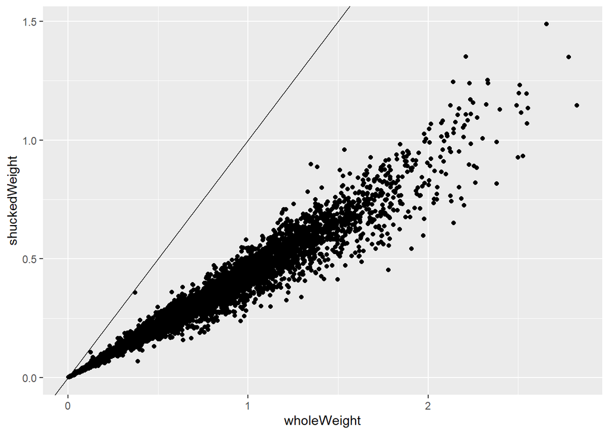

```r
# Scatterplot of shuckedWeight by wholeWeight add y=x line
ggplot(abaloneKeep, aes(x=wholeWeight, y=shuckedWeight)) +
    geom_point() +
    geom_abline(intercept=0, slope=1)
```

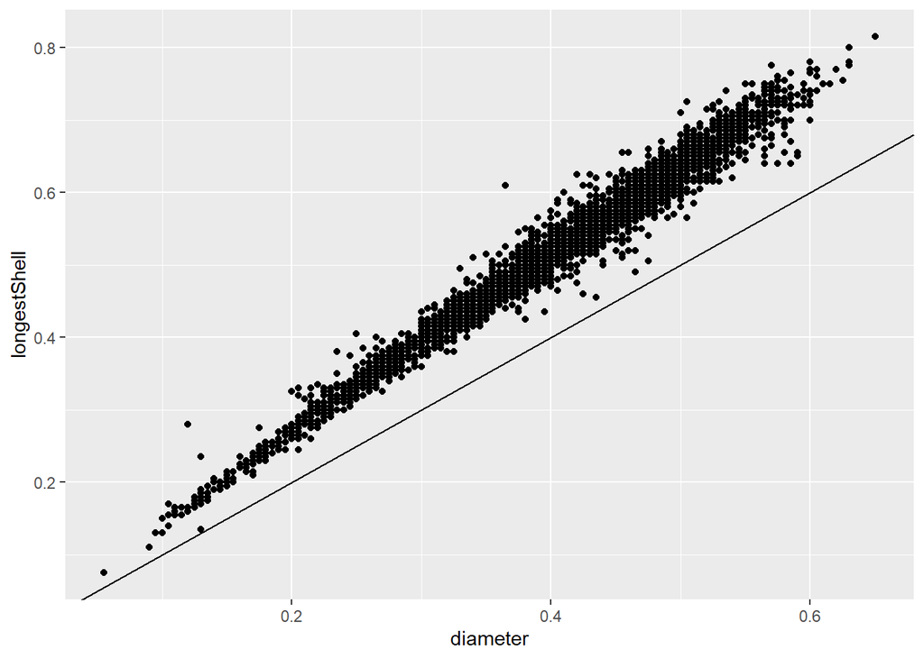

```r
# Scatterplot of length by diameter add y=x line
ggplot(abaloneKeep, aes(x=diameter, y=longestShell)) +
    geom_point() +
    geom_abline(intercept=0, slope=1)
```

Chapter 3 - Data Exploration

Exploratory Data Analysis:

- Can get summary statistics in R using several different packages and functions
  - summary()
  - Hmisc::describe()
  - psych::describe()
- Can use the dplyr::summarize() to create new names for statistics
- Can use the dplyr::summarize_all() to get key statistic
  - myDF %>% select(a, b) %>% summarize_all(funs(mean, sd))
- Can also use the dplyr::group_by() to get the output summarized by values of a key variable

Correlations and T-tests:

- Can assess the strenght of correlations using psych::corr.test()
- Can use Ggally::ggpairs() to get the pairs plot, and density plots for all of the key variables
  - Can add aes(color=a) to have the charts colored by levels of variable a
- Can add the counts in several ways, including use of an extra group_by statement
  - myDF %>% select(a, b) %>% group_by(a) %>% group_by(N = n(), add=TRUE) %>% summarize_all(funs(mean, sd))
- Can perform F tests for equal variances, and t-tests for equal means
  - var.test(a ~ b, data = myDF)
  - t.test(a ~ b, data = myDF) # unpooled t-test is the default
  - t.test(a ~ b, data = myDF, var.equal = TRUE) # pooled t-test to over-ride defaults

Categorical Data: Analyze and Visualize:

- Can use the table() command inside the with() command
  - myDF %>% with(table(a))
- Can create contingency tables using either table() or gmodels::CrossTable()
  - gmodels::CrossTable(chisq=TRUE) # will run a Chi-squared test on the table resulting from the gmodels call
  - Can also include prop.r=, prop.t=, prop.chisq=, expected= options inside gmodels::CrossTable()
- Can get the mosaicplot using mosaicplot()
  - mosaicplot(a ~ b, data=myDF, color=c(“red”, “blue”), main=“myTitle”)

Example code includes:

```r
# Run describe() from Hmisc for sex, length, diameter, height
abaloneKeep %>%
    select(type, longestShell, diameter, height) %>%
    Hmisc::describe()
```

```
## .
##
##  4  Variables      4169  Observations
## --------------------------------------------------------------------------------
## type
##        n  missing distinct
##     4169        0        3
##
## Value          F     I     M
## Frequency   1306  1335  1528
## Proportion 0.313 0.320 0.367
## --------------------------------------------------------------------------------
## longestShell
##        n  missing distinct     Info     Mean      Gmd      .05      .10
##     4169        0      134        1   0.5243   0.1341    0.295    0.355
##      .25      .50      .75      .90      .95
##    0.450    0.545    0.615    0.660    0.690
##
## lowest : 0.075 0.110 0.130 0.135 0.140, highest: 0.770 0.775 0.780 0.800 0.815
## --------------------------------------------------------------------------------
## diameter
##        n  missing distinct     Info     Mean      Gmd      .05      .10
##     4169        0      111        1   0.4081   0.1111    0.220    0.265
##      .25      .50      .75      .90      .95
##    0.350    0.425    0.480    0.525    0.545
##
## lowest : 0.055 0.090 0.095 0.100 0.105, highest: 0.615 0.620 0.625 0.630 0.650
## --------------------------------------------------------------------------------
## height
##        n  missing distinct     Info     Mean      Gmd      .05      .10
##     4169        0       49    0.998   0.1394  0.04351    0.075    0.090
##      .25      .50      .75      .90      .95
##    0.115    0.140    0.165    0.185    0.200
##
## lowest : 0.010 0.015 0.020 0.025 0.030, highest: 0.230 0.235 0.240 0.250 0.515
## --------------------------------------------------------------------------------
```

```r
# Run describe() from psych for length, diameter, height
abaloneKeep %>%
    select(longestShell, diameter, height) %>%
    psych::describe()
```

```
##              vars    n mean   sd median trimmed  mad  min  max range  skew
## longestShell    1 4169 0.52 0.12   0.55    0.53 0.12 0.08 0.82  0.74 -0.64
## diameter        2 4169 0.41 0.10   0.42    0.41 0.10 0.06 0.65  0.60 -0.61
## height          3 4169 0.14 0.04   0.14    0.14 0.04 0.01 0.52  0.50 -0.03
##              kurtosis se
## longestShell     0.07  0
## diameter        -0.04  0
## height           1.81  0
```

```r
# Run summary() for shuckedWeight and wholeWeight
abaloneKeep %>%
    select(shuckedWeight, wholeWeight) %>%
    summary()
```

```
##  shuckedWeight     wholeWeight
##  Min.   :0.0010   Min.   :0.0020
##  1st Qu.:0.1860   1st Qu.:0.4425
##  Median :0.3360   Median :0.8015
##  Mean   :0.3595   Mean   :0.8298
##  3rd Qu.:0.5030   3rd Qu.:1.1540
##  Max.   :1.4880   Max.   :2.8255
```

```r
# Get mean and sd for length
abaloneKeep %>%
    summarize(mean_length = mean(longestShell), sd_length = sd(longestShell))
```

```
## # A tibble: 1 x 2
##   mean_length sd_length
##         <dbl>     <dbl>
## 1       0.524     0.120
```

```r
# Get mean and sd for height and diameter
abaloneKeep %>%
    select(height, diameter) %>%
    summarise_all(list(~mean(.), ~sd(.)))
```

```
## # A tibble: 1 x 4
##   height_mean diameter_mean height_sd diameter_sd
##         <dbl>         <dbl>     <dbl>       <dbl>
## 1       0.139         0.408    0.0388      0.0992
```

```r
# Get min, mean, sd, median, and max for age by sex
abaloneKeep %>%
    group_by(type) %>%
    select(type, age) %>%
    summarise_all(list(~min(.), ~mean(.), ~sd(.), ~median(.), ~max(.)))
```

```
## # A tibble: 3 x 6
##   type    min  mean    sd median   max
##   <fct> <dbl> <dbl> <dbl>  <dbl> <dbl>
## 1 F       6.5 12.6   3.10   11.5  30.5
## 2 I       2.5  9.40  2.51    9.5  22.5
## 3 M       4.5 12.2   3.03   11.5  28.5
```

```r
# Get median, 25th, 75th percentiles for wholeWeight by adult
abaloneKeep %>%
    group_by(adult) %>%
    select(adult, wholeWeight) %>%
    summarise(median_wweight = median(wholeWeight),
              q1_wweight = quantile(wholeWeight, probs = 0.25),
              q3_wweight = quantile(wholeWeight, probs = 0.75)
              )
```

```
## # A tibble: 2 x 4
##   adult median_wweight q1_wweight q3_wweight
##   <lgl>          <dbl>      <dbl>      <dbl>
## 1 FALSE          0.385      0.208      0.601
## 2 TRUE           1.00       0.702      1.29
```

```r
# Get correlations age and weights with corr.test()
abaloneKeep %>%
    select(age, wholeWeight, shuckedWeight, shellWeight, visceraWeight) %>%
    psych::corr.test()
```

```
## Call:psych::corr.test(x = .)
## Correlation matrix
##                age wholeWeight shuckedWeight shellWeight visceraWeight
## age           1.00        0.54          0.42        0.63          0.50
## wholeWeight   0.54        1.00          0.97        0.96          0.97
## shuckedWeight 0.42        0.97          1.00        0.88          0.93
## shellWeight   0.63        0.96          0.88        1.00          0.91
## visceraWeight 0.50        0.97          0.93        0.91          1.00
## Sample Size
## [1] 4169
## Probability values (Entries above the diagonal are adjusted for multiple tests.)
##               age wholeWeight shuckedWeight shellWeight visceraWeight
## age             0           0             0           0             0
## wholeWeight     0           0             0           0             0
## shuckedWeight   0           0             0           0             0
## shellWeight     0           0             0           0             0
## visceraWeight   0           0             0           0             0
##
##  To see confidence intervals of the correlations, print with the short=FALSE option
```

```r
# Get correlations age and dimensions with corr.test()
abaloneKeep %>%
    select(age, longestShell, diameter, height) %>%
    psych::corr.test()
```

```
## Call:psych::corr.test(x = .)
## Correlation matrix
##               age longestShell diameter height
## age          1.00         0.56     0.57   0.60
## longestShell 0.56         1.00     0.99   0.89
## diameter     0.57         0.99     1.00   0.90
## height       0.60         0.89     0.90   1.00
## Sample Size
## [1] 4169
## Probability values (Entries above the diagonal are adjusted for multiple tests.)
##              age longestShell diameter height
## age            0            0        0      0
## longestShell   0            0        0      0
## diameter       0            0        0      0
## height         0            0        0      0
##
##  To see confidence intervals of the correlations, print with the short=FALSE option
```

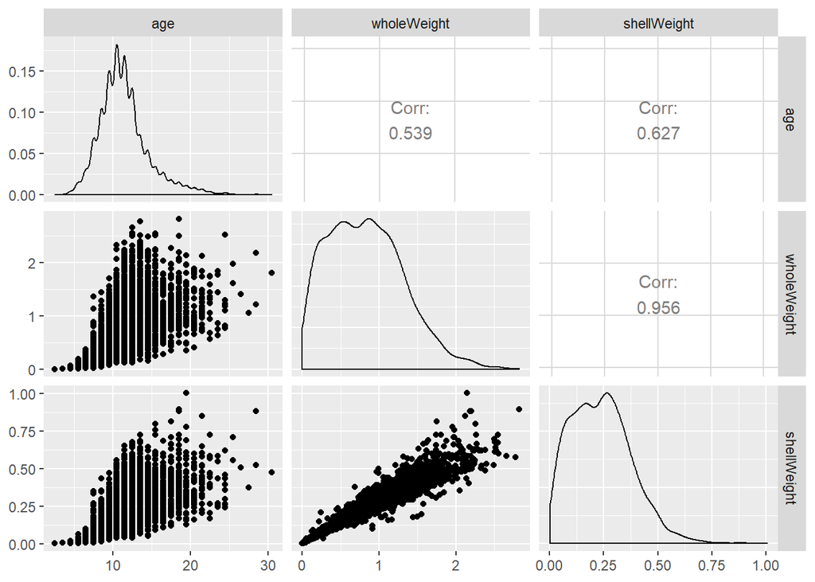

```r
# Make ggpairs plot of age, wholeWeight, shellWeight
abaloneKeep %>%
    select(age, wholeWeight, shellWeight) %>%
    GGally::ggpairs()
```

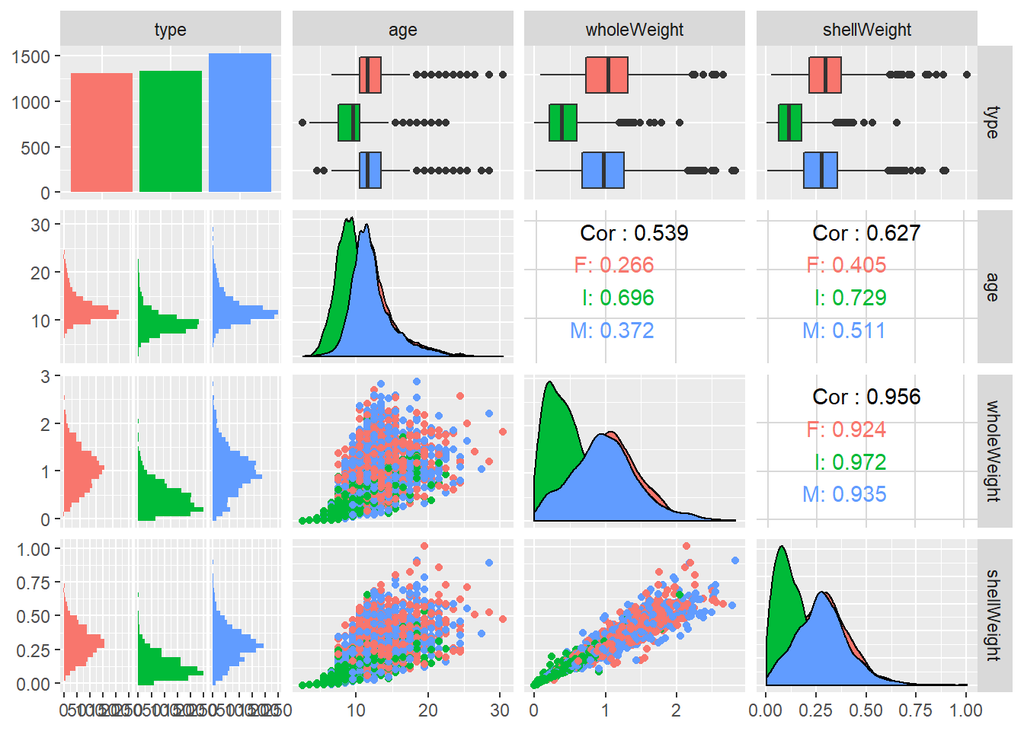

```r
# Make ggpairs plot of age, wholeWeight, shellWeight
abaloneKeep %>%
    select(type, age, wholeWeight, shellWeight) %>%
    GGally::ggpairs(aes(color=type))
```

```r
# Get n, mean, sd for length by adult groups
abaloneKeep %>%
    select(longestShell, adult) %>%
    group_by(adult) %>%
    group_by(N = n(), add = TRUE) %>%
    summarise_all(list(~mean(.), ~sd(.)))
```

```
## # A tibble: 2 x 4
## # Groups:   adult [2]
##   adult     N  mean     sd
##   <lgl> <int> <dbl>  <dbl>
## 1 FALSE  1335 0.428 0.109
## 2 TRUE   2834 0.570 0.0958
```

```r
# Run equal variance and pooled t-tests of length by adult
var.test(longestShell ~ adult, data = abaloneKeep)
```

```
##
##  F test to compare two variances
##
## data:  longestShell by adult
## F = 1.2881, num df = 1334, denom df = 2833, p-value = 4.45e-08
## alternative hypothesis: true ratio of variances is not equal to 1
## 95 percent confidence interval:
##  1.175676 1.413382
## sample estimates:
## ratio of variances
##           1.288066
```

```r
t.test(longestShell ~ adult, data = abaloneKeep, var.equal = TRUE)
```

```
##
##  Two Sample t-test
##
## data:  longestShell by adult
## t = -42.528, df = 4167, p-value < 2.2e-16
## alternative hypothesis: true difference in means is not equal to 0
## 95 percent confidence interval:
##  -0.1478770 -0.1348435
## sample estimates:
## mean in group FALSE  mean in group TRUE
##           0.4282322           0.5695924
```

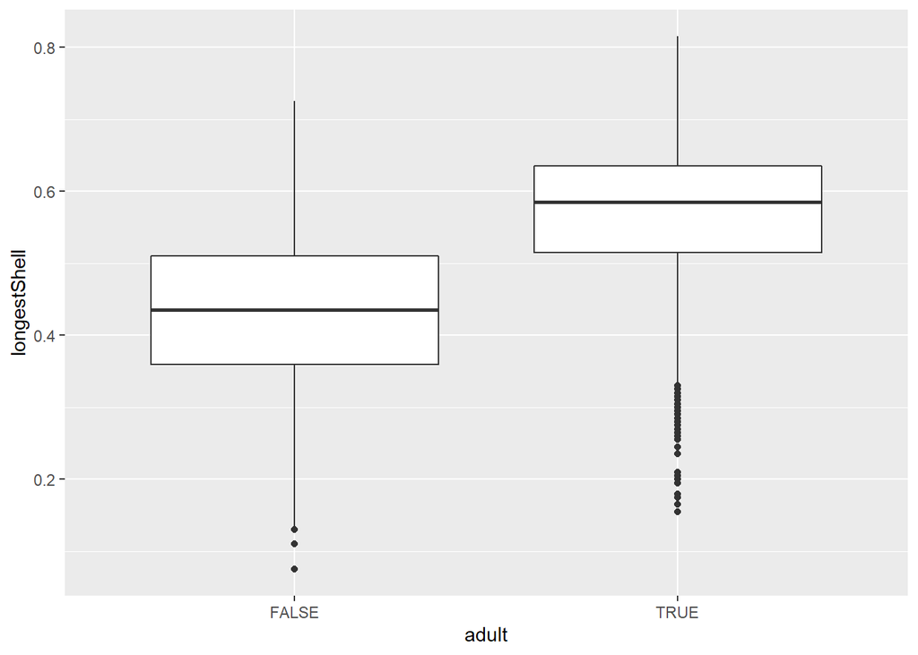

```r
# Make boxplots of length by adult
ggplot(abaloneKeep, aes(x=adult, y=longestShell)) +
    geom_boxplot()
```

```r
# Create frequency table of sex by agecat
tablesexage <- abaloneKeep %>%
    with(table(type, agecat))

# Run chi-square test using tablesexage
chisq.test(tablesexage)
```

```
##
##  Pearson's Chi-squared test
##
## data:  tablesexage
## X-squared = 1087.1, df = 2, p-value < 2.2e-16
```

```r
# Use CrossTabs, run chisq test
abaloneKeep %>%
    with(gmodels::CrossTable(type, agecat, chisq=TRUE, prop.c = FALSE, prop.t = FALSE,
                             prop.chisq = FALSE, expected = TRUE
                             )
         )
```

```
##
##
##    Cell Contents
## |-------------------------|
## |                       N |
## |              Expected N |
## |           N / Row Total |
## |-------------------------|
##
##
## Total Observations in Table:  4169
##
##
##              | agecat
##         type |         < 10.5 | 10.5 and older |      Row Total |
## -------------|----------------|----------------|----------------|
##            F |            185 |           1121 |           1306 |
##              |        438.257 |        867.743 |                |
##              |          0.142 |          0.858 |          0.313 |
## -------------|----------------|----------------|----------------|
##            I |            915 |            420 |           1335 |
##              |        447.989 |        887.011 |                |
##              |          0.685 |          0.315 |          0.320 |
## -------------|----------------|----------------|----------------|
##            M |            299 |           1229 |           1528 |
##              |        512.754 |       1015.246 |                |
##              |          0.196 |          0.804 |          0.367 |
## -------------|----------------|----------------|----------------|
## Column Total |           1399 |           2770 |           4169 |
## -------------|----------------|----------------|----------------|
##
##
## Statistics for All Table Factors
##
##
## Pearson's Chi-squared test
## ------------------------------------------------------------
## Chi^2 =  1087.102     d.f. =  2     p =  8.686576e-237
##
##
##
```

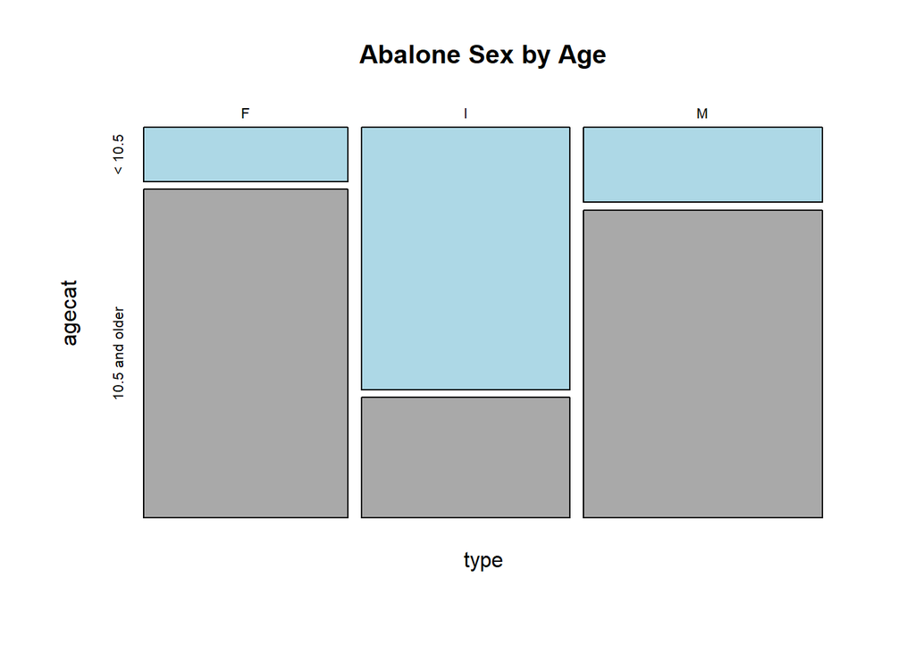

```r
# Make mosaicplot of sex by agecat
mosaicplot(type ~ agecat, data = abaloneKeep,
           color = c("light blue", "dark grey"), main = "Abalone Sex by Age"
           )
```

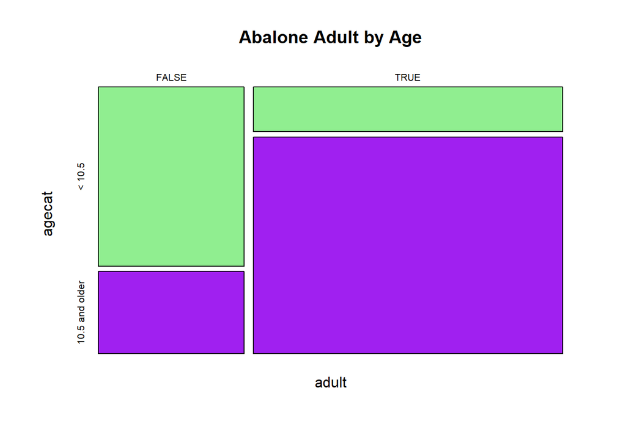

```r
# Make mosaicplot of adult by agecat
mosaicplot(adult ~ agecat, data = abaloneKeep,
           color = c("light green", "purple"), main = "Abalone Adult by Age"
           )
```

```r
# Add shellcat to abaloneKeep
abaloneKeep <- abaloneKeep %>%
    mutate(shellcat = ifelse(shellWeight <= 0.235, "<= 0.235g", "> 0.235g"))

# Run chisq.test of agecat by shellcat
tableageshell <- abaloneKeep %>%
    with(table(agecat, shellcat))

chisq.test(tableageshell)
```

```
##
##  Pearson's Chi-squared test with Yates' continuity correction
##
## data:  tableageshell
## X-squared = 1263.3, df = 1, p-value < 2.2e-16
```

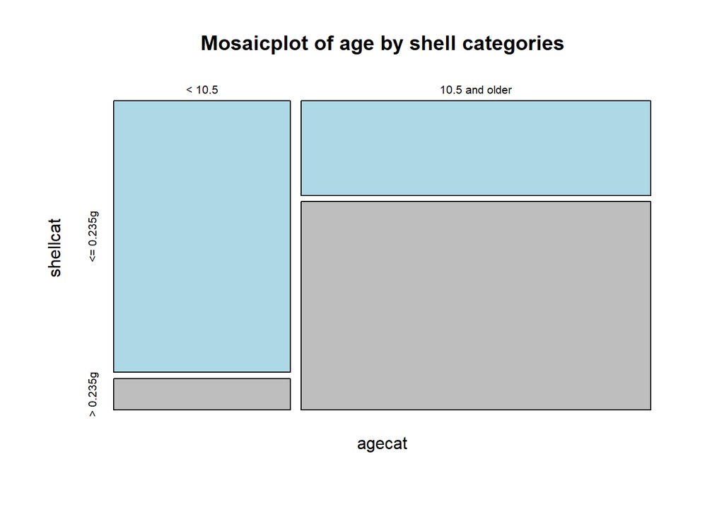

```r
# Make mosaicplot of agecat by shellcat
mosaicplot(agecat ~ shellcat, data = abaloneKeep,
           color = c("light blue", "grey"), main = "Mosaicplot of age by shell categories"
           )
```

Chapter 4 - Models and Presentation

Working with Output Objects:

- Can use summary() to get the summary of various types of objects
  - class(summary(x)) # matrix, which means that you can use column and row filtering
- The dplyr::summarize_all() creates a data.frame object
  - davissmall <- daviskeep %>% select(weight, height) %>% summarize_all(funs(mean, sd))
  - str(davissmall) # 1 obs of 4 variables
- The psych::describe() function produces a data.frame that is also ‘psych’ and ‘describe’

Working with Lists:

- Lists are more flexible than data frames; can combine objects of different lengths and data types
- Can set the names of objects in the list using names()
- Can extract objects out of the list using the $ operator
  - myList$myVar
- The Hmisc::describe() outputs lists of lists
- Many times, the output of a function will be a list of lists
  - names(myOutput) # get the names
  - myOutput$myName # extract one of the elements

ANOVA and Linear Models:

- Can add na.rm=TRUE to eliminate NA and NaN from the calculations and functions
- Can run ANOVA in R using a combination of aov() and TukeyHSD()
  - myAOV <- aov(y ~ x, data=myDF)
  - TukeyHSD(myAOV)
  - Note that the aov() function will automatically remove missing values; no need for na.rm=TRUE
- Linear regression in R can be run using the lm() function
  - myLM <- lm(y ~ x, data=myDF)

Final Models Evaluation:

- Can run multiple linear models and run summary() on each to compare statistics
- Can also run AIC using AIC(modA, modB)
- Can run regressions on a subset of the data using subset=
  - lm(y ~ x, data=myDF, subset=(myCol==“myVar”))

Wrap Up:

- R environment, packages, and plotting
- Objects in R
- Exploratory data analysis, statistical tests
- Saving output objects and running analyses

Example code includes:

```r
# Save summary stats output for 3 requested weights
absummary <- abaloneKeep %>%
    select(wholeWeight, shuckedWeight, shellWeight) %>%
    summary()

# Pull columns 1 to 2 out of absummary
absummary[, 1:2]
```

```
##   wholeWeight     shuckedWeight
##  Min.   :0.0020   Min.   :0.0010
##  1st Qu.:0.4425   1st Qu.:0.1860
##  Median :0.8015   Median :0.3360
##  Mean   :0.8298   Mean   :0.3595
##  3rd Qu.:1.1540   3rd Qu.:0.5030
##  Max.   :2.8255   Max.   :1.4880
```

```r
# Save describe from psych output for weights as abpsych
abpsych <- abaloneKeep %>%
    select(wholeWeight, shuckedWeight, shellWeight) %>%
    psych::describe()

# Display the mad element from abpsych
data.frame(abpsych)[,"mad",drop=FALSE]
```

```
##                     mad
## wholeWeight   0.5278056
## shuckedWeight 0.2349921
## shellWeight   0.1482600
```

```r
# Save output from summarise_all() for diameter
abdiam <- abaloneKeep %>%
    select(diameter) %>%
    summarise_all(list(~mean(.), ~sd(.), ~median(.), ~min(.), ~max(.)))

# Use str() to see class of abdiam and names of elements
str(abdiam)
```

```
## Classes 'tbl_df', 'tbl' and 'data.frame':    1 obs. of  5 variables:
##  $ mean  : num 0.408
##  $ sd    : num 0.0992
##  $ median: num 0.425
##  $ min   : num 0.055
##  $ max   : num 0.65
```

```r
# Use $ selector to display sd
abdiam$sd
```

```
## [1] 0.09917095
```

```r
# Save output from summarise_all() for diameter by sex
absexdiam <- abaloneKeep %>%
    group_by(type) %>%
    select(type, diameter) %>%
    summarize_all(list(~mean(.), ~sd(.), ~median(.), ~min(.), ~max(.)))

# Get structure of absexdiam
str(absexdiam)
```

```
## Classes 'tbl_df', 'tbl' and 'data.frame':    3 obs. of  6 variables:
##  $ type  : Factor w/ 3 levels "F","I","M": 1 2 3
##  $ mean  : num  0.455 0.327 0.439
##  $ sd    : num  0.0709 0.0882 0.0844
##  $ median: num  0.465 0.335 0.455
##  $ min   : num  0.195 0.055 0.11
##  $ max   : num  0.65 0.55 0.63
```

```r
# Use filter() function to extract row for sex == "I"
absexdiam %>% filter(type == "I")
```

```
## # A tibble: 1 x 6
##   type   mean     sd median   min   max
##   <fct> <dbl>  <dbl>  <dbl> <dbl> <dbl>
## 1 I     0.327 0.0882  0.335 0.055  0.55
```

```r
# Save output from Hmisc::describe(), view class of output
abhmisc <- abaloneKeep %>%
    select(wholeWeight, shuckedWeight, shellWeight) %>%
    Hmisc::describe()

# Get structure of abhmisc
str(abhmisc)
```

```
## List of 3
##  $ wholeWeight  :List of 7
##   ..$ descript : chr "wholeWeight"
##   ..$ units    : NULL
##   ..$ format   : NULL
##   ..$ counts   : Named chr [1:13] "4169" "0" "2426" "1" ...
##   .. ..- attr(*, "names")= chr [1:13] "n" "missing" "distinct" "Info" ...
##   ..$ roundedTo: num 0.05
##   ..$ values   :List of 2
##   .. ..$ value    : num [1:54] 0 0.05 0.1 0.15 0.2 0.25 0.3 0.35 0.4 0.45 ...
##   .. ..$ frequency: num [1:54(1d)] 23 79 104 109 165 119 133 126 134 158 ...
##   ..$ extremes : Named num [1:10] 0.002 0.008 0.0105 0.013 0.014 ...
##   .. ..- attr(*, "names")= chr [1:10] "L1" "L2" "L3" "L4" ...
##   ..- attr(*, "class")= chr "describe"
##  $ shuckedWeight:List of 7
##   ..$ descript : chr "shuckedWeight"
##   ..$ units    : NULL
##   ..$ format   : NULL
##   ..$ counts   : Named chr [1:13] "4169" "0" "1515" "1" ...
##   .. ..- attr(*, "names")= chr [1:13] "n" "missing" "distinct" "Info" ...
##   ..$ roundedTo: num 0.02
##   ..$ values   :List of 2
##   .. ..$ value    : num [1:66] 0 0.02 0.04 0.06 0.08 0.1 0.12 0.14 0.16 0.18 ...
##   .. ..$ frequency: num [1:66(1d)] 27 75 98 108 132 128 114 106 154 132 ...
##   ..$ extremes : Named num [1:10] 0.001 0.0025 0.0045 0.005 0.0055 ...
##   .. ..- attr(*, "names")= chr [1:10] "L1" "L2" "L3" "L4" ...
##   ..- attr(*, "class")= chr "describe"
##  $ shellWeight  :List of 7
##   ..$ descript : chr "shellWeight"
##   ..$ units    : NULL
##   ..$ format   : NULL
##   ..$ counts   : Named chr [1:13] "4169" "0" "924" "1" ...
##   .. ..- attr(*, "names")= chr [1:13] "n" "missing" "distinct" "Info" ...
##   ..$ roundedTo: num 0.01
##   ..$ values   :List of 2
##   .. ..$ value    : num [1:82] 0 0.01 0.02 0.03 0.04 0.05 0.06 0.07 0.08 0.09 ...
##   .. ..$ frequency: num [1:82(1d)] 17 49 49 81 75 73 85 105 98 91 ...
##   ..$ extremes : Named num [1:10] 0.0015 0.003 0.0035 0.004 0.005 ...
##   .. ..- attr(*, "names")= chr [1:10] "L1" "L2" "L3" "L4" ...
##   ..- attr(*, "class")= chr "describe"
##  - attr(*, "descript")= chr "."
##  - attr(*, "dimensions")= int [1:2] 4169 3
##  - attr(*, "class")= chr "describe"
```

```r
# View shuckedWeight statistics from abhmisc
abhmisc$shuckedWeight
```

```
## shuckedWeight
##        n  missing distinct     Info     Mean      Gmd      .05      .10
##     4169        0     1515        1   0.3595    0.248   0.0522   0.0865
##      .25      .50      .75      .90      .95
##   0.1860   0.3360   0.5030   0.6473   0.7406
##
## lowest : 0.0010 0.0025 0.0045 0.0050 0.0055, highest: 1.2455 1.2530 1.3485 1.3510 1.4880
```

```r
# View shuckedWeight extremes from abhmisc
abhmisc$shuckedWeight$extremes
```

```
##     L1     L2     L3     L4     L5     H5     H4     H3     H2     H1
## 0.0010 0.0025 0.0045 0.0050 0.0055 1.2455 1.2530 1.3485 1.3510 1.4880
```

```r
# Save correlation from psych::corr.test(), run str()
abcorr <- abaloneKeep %>%
    select(age, wholeWeight, shuckedWeight, shellWeight, visceraWeight) %>%
    psych::corr.test()

# Display Pearson's r's and p-values from abage
abcorr$r
```

```
##                     age wholeWeight shuckedWeight shellWeight visceraWeight
## age           1.0000000   0.5392897     0.4209993   0.6272848     0.5026709
## wholeWeight   0.5392897   1.0000000     0.9704731   0.9558900     0.9663295
## shuckedWeight 0.4209993   0.9704731     1.0000000   0.8840860     0.9329276
## shellWeight   0.6272848   0.9558900     0.8840860   1.0000000     0.9080238
## visceraWeight 0.5026709   0.9663295     0.9329276   0.9080238     1.0000000
```

```r
abcorr$p
```

```
##                         age  wholeWeight shuckedWeight shellWeight
## age            0.000000e+00 7.43105e-313 8.678977e-179           0
## wholeWeight   2.477017e-313  0.00000e+00  0.000000e+00           0
## shuckedWeight 8.678977e-179  0.00000e+00  0.000000e+00           0
## shellWeight    0.000000e+00  0.00000e+00  0.000000e+00           0
## visceraWeight 6.978477e-266  0.00000e+00  0.000000e+00           0
##               visceraWeight
## age           1.395695e-265
## wholeWeight    0.000000e+00
## shuckedWeight  0.000000e+00
## shellWeight    0.000000e+00
## visceraWeight  0.000000e+00
```

```r
# Perform pooled t-test of length by adult, save as abttest
abttest <- t.test(longestShell ~ adult, data = abaloneKeep, var.equal=TRUE)

# Display statistic, parameter and conf.int from abttest
abttest$statistic
```

```
##         t
## -42.52755
```

```r
abttest$parameter
```

```
##   df
## 4167
```

```r
abttest$conf.int
```

```
## [1] -0.1478770 -0.1348435
## attr(,"conf.level")
## [1] 0.95
```

```r
# Create frequency table of sex by agecat
tablesexage <- abaloneKeep %>%
    with(table(type, agecat))

# Chi-square test using tablesexage
cssexage <- chisq.test(tablesexage)

# Display expected values and p.value from cssexage
cssexage$expected
```

```
##     agecat
## type   < 10.5 10.5 and older
##    F 438.2571       867.7429
##    I 447.9887       887.0113
##    M 512.7541      1015.2459
```

```r
cssexage$p.value
```

```
## [1] 8.686576e-237
```

```r
# Compute n(), mean(), sd() and var() of age by sex
abaloneKeep %>%
    group_by(type) %>%
    group_by(N=n(), add=TRUE) %>%
    select(type, age) %>%
    summarise_all(list(~mean(.), ~sd(.), ~var(.)))
```

```
## # A tibble: 3 x 5
## # Groups:   type [3]
##   type      N  mean    sd   var
##   <fct> <int> <dbl> <dbl> <dbl>
## 1 F      1306 12.6   3.10  9.64
## 2 I      1335  9.40  2.51  6.32
## 3 M      1528 12.2   3.03  9.16
```

```r
# Run aov() of age by sex, save as abaov
abaov <- aov(age ~ type, data = abaloneKeep)

# Run summary() of abaov
summary(abaov)
```

```
##               Df Sum Sq Mean Sq F value Pr(>F)
## type           2   8312    4156   494.8 <2e-16 ***
## Residuals   4166  34994       8
## ---
## Signif. codes:  0 '***' 0.001 '**' 0.01 '*' 0.05 '.' 0.1 ' ' 1
```

```r
# Perform TukeyHSD posthoc pairwise tests on abaov
TukeyHSD(abaov)
```

```
##   Tukey multiple comparisons of means
##     95% family-wise confidence level
##
## Fit: aov(formula = age ~ type, data = abaloneKeep)
##
## $type
##           diff        lwr        upr     p adj
## I-F -3.2328234 -3.4972883 -2.9683586 0.0000000
## M-F -0.4262025 -0.6822748 -0.1701302 0.0002853
## M-I  2.8066210  2.5520527  3.0611893 0.0000000
```

```r
# Run lm() of age by shuckedWeight, save output as lmshucked
lmshucked <- lm(age ~ shuckedWeight, data = abaloneKeep)

# Display coefficients element from lmshucked
lmshucked$coefficients
```

```
##   (Intercept) shuckedWeight
##      9.243295      6.110826
```

```r
# Save summary() output of lmshucked as smrylmshucked
smrylmshucked <- summary(lmshucked)

# Show r.squared and adj.r.squared elements of smrylmshucked
smrylmshucked$r.squared
```

```
## [1] 0.1772404
```

```r
smrylmshucked$adj.r.squared
```

```
## [1] 0.1770429
```

```r
# Run lm() for age by shuckedWeight and by shellWeight
lmshucked <- lm(age ~ shuckedWeight, data = abaloneKeep)
lmshell <- lm(age ~ shellWeight, data = abaloneKeep)

# Run summary() for each model fit and save results
smrylmshucked <- summary(lmshucked)
smrylmshell <- summary(lmshell)

# Display r.squared for both models
smrylmshucked$r.squared
```

```
## [1] 0.1772404
```

```r
smrylmshell$r.squared
```

```
## [1] 0.3934863
```

```r
# Compare AICs for both models
AIC(lmshucked, lmshell)
```

```
##           df      AIC
## lmshucked  3 20781.81
## lmshell    3 19510.53
```

```r
# Save model output and output of model summary for infants
modelInfants <- lm(age ~ shellWeight, data = abaloneKeep, subset = (type == "I"))
summaryInfants <- summary(modelInfants)

# Save model output and output of model summary for females
modelFemales <- lm(age ~ shellWeight, data = abaloneKeep, subset = (type == "F"))
summaryFemales <- summary(modelFemales)

# Save model output and output of model summary for males
modelMales <- lm(age ~ shellWeight, data = abaloneKeep, subset = (type == "M"))
summaryMales <- summary(modelMales)

# Display each model r.squared values
t(data.frame(summaryInfants$r.squared, summaryFemales$r.squared, summaryMales$r.squared))
```

```
##                               [,1]
## summaryInfants.r.squared 0.5311030
## summaryFemales.r.squared 0.1642747
## summaryMales.r.squared   0.2611177
```

### *Quantitative Risk Management in R*

Chapter 1 - Exploring Market Risk-Factor Data

Introduction - Alexander McNeil, author of book “Quantitative Risk Management” (contains theory behind the course):

- Can also review on qrmtutorial.org (helper materials to the book)
- Packages qrmdata (large data sets) and qrmtools (useful functions) are available as R packages
- The goal of QRM is to measure and then manage the risk of a portfolio
  - Can manage risk by selling assets, buying assets (diversify), maintaining sufficient capital, etc.
- Value at risk (VaR) is an important concept in this course and in this space
  - Dependent on many risk factors - interest rates, index prices, exchange rates, etc.

Risk-factor returns:

- Changes in risk factors are risk-factor returns or returns
- Suppose that Zt is a time series of risk factor values
  - Simple returns: Xt = Zt - Z(t-1) # used for values that are very closest to zero
  - Relative returns: Xt = (Zt - Z(t-1)) / Z(t-1) # easiest to interpret
  - Log returns: Xt = ln(Zt) - ln(Z(t-1)) # most commonly used (desirable feature of non-negativity, very close to relative returns for small values, particularly easy to aggregate, geometrics Brownian motion)
- In practice, log returns tend not to be normally distributed
  - logR <- diff(log(mySeries))[-1] # first value will be NA and is not helpful for plotting

Aggregating log returns:

- Suppose you have daily log-returns Xt - can just sum the log returns over the time period of interest
  - ln(Z(t+5)) - ln(Zt) = sum-of-relevant-Zt
  - Can use apply.weekly() or apply.monthly() from the xts package # need the FUN=sum for each of these

Exploring other risk factors - commodities prices and zero-coupon bonds data:

- Suppose p(t, T) is the price at time t of a bond paying back 1 unit at time T
  - The yield is frequently considered to be the risk factor - comparable across different maturities, T
  - y(t, T) = -ln(p(t, T)) / (T - t)
  - The mapping T for y(t, T) defines the yield curve - some arguments about whether to use simple returns or log returns on yields

Example code includes:

```r
library(xts)
library(zoo)

# Load DJ index
data(DJ, package='qrmdata')

# Show head() and tail() of DJ index
head(DJ)
```

```
##               ^DJI
## 1985-01-29 1292.62
## 1985-01-30 1287.88
## 1985-01-31 1286.77
## 1985-02-01 1277.72
## 1985-02-04 1290.08
## 1985-02-05 1285.23
```

```r
tail(DJ)
```

```
##                ^DJI
## 2015-12-23 17602.61
## 2015-12-24 17552.17
## 2015-12-28 17528.27
## 2015-12-29 17720.98
## 2015-12-30 17603.87
## 2015-12-31 17425.03
```

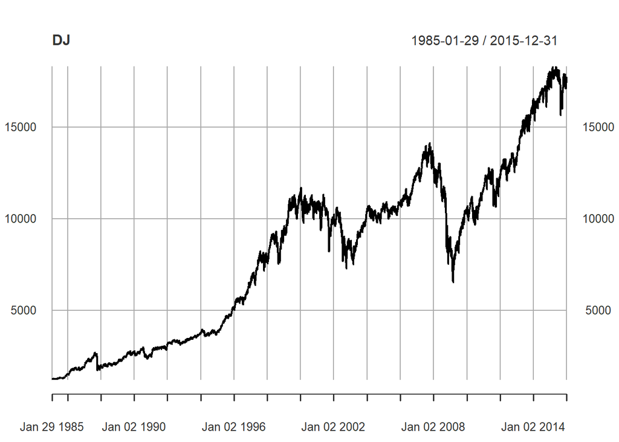

```r
# Plot DJ index
plot(DJ)
```

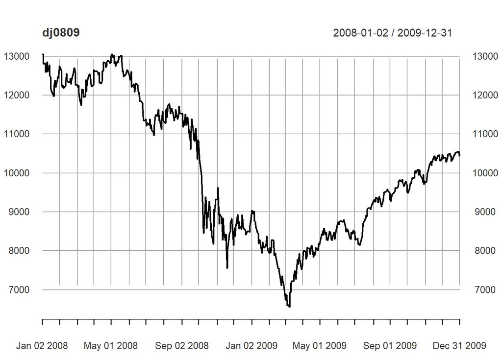

```r
# Extract 2008-2009 and assign to dj0809
dj0809 <- DJ["2008/2009"]

# Plot dj0809
plot(dj0809)
```

```r
# Load DJ constituents data
data("DJ_const", package='qrmdata')

# Apply names() and head() to DJ_const
names(DJ_const)
```

```
##  [1] "AAPL" "AXP"  "BA"   "CAT"  "CSCO" "CVX"  "DD"   "DIS"  "GE"   "GS"
## [11] "HD"   "IBM"  "INTC" "JNJ"  "JPM"  "KO"   "MCD"  "MMM"  "MRK"  "MSFT"
## [21] "NKE"  "PFE"  "PG"   "TRV"  "UNH"  "UTX"  "V"    "VZ"   "WMT"  "XOM"
```

```r
head(DJ_const)
```

```
##            AAPL AXP       BA      CAT CSCO CVX       DD      DIS       GE GS HD
## 1962-01-02   NA  NA 0.212905 0.593184   NA  NA 1.227958 0.061014 0.145967 NA NA
## 1962-01-03   NA  NA 0.217163 0.598964   NA  NA 1.229230 0.061832 0.144501 NA NA
## 1962-01-04   NA  NA 0.215034 0.614372   NA  NA 1.220331 0.061832 0.142794 NA NA
## 1962-01-05   NA  NA 0.210773 0.620152   NA  NA 1.187280 0.062039 0.139132 NA NA
## 1962-01-08   NA  NA 0.211306 0.624001   NA  NA 1.169484 0.061832 0.138889 NA NA
## 1962-01-09   NA  NA 0.211839 0.629777   NA  NA 1.173297 0.063060 0.139620 NA NA
##                 IBM INTC JNJ JPM       KO MCD MMM MRK MSFT NKE PFE PG TRV UNH
## 1962-01-02 2.346625   NA  NA  NA 0.031031  NA  NA  NA   NA  NA  NA NA  NA  NA
## 1962-01-03 2.367136   NA  NA  NA 0.030339  NA  NA  NA   NA  NA  NA NA  NA  NA
## 1962-01-04 2.343548   NA  NA  NA 0.030571  NA  NA  NA   NA  NA  NA NA  NA  NA
## 1962-01-05 2.297395   NA  NA  NA 0.029879  NA  NA  NA   NA  NA  NA NA  NA  NA
## 1962-01-08 2.254319   NA  NA  NA 0.029570  NA  NA  NA   NA  NA  NA NA  NA  NA
## 1962-01-09 2.280983   NA  NA  NA 0.030110  NA  NA  NA   NA  NA  NA NA  NA  NA
##            UTX  V VZ WMT XOM
## 1962-01-02  NA NA NA  NA  NA
## 1962-01-03  NA NA NA  NA  NA
## 1962-01-04  NA NA NA  NA  NA
## 1962-01-05  NA NA NA  NA  NA
## 1962-01-08  NA NA NA  NA  NA
## 1962-01-09  NA NA NA  NA  NA
```